# TCS_Insurance_Nationwide_Hackathon

## Outlier Treatment

Outlier Treatment is very important because Outlier may cause deviation in Mean and Median values which affects the output of the predictions

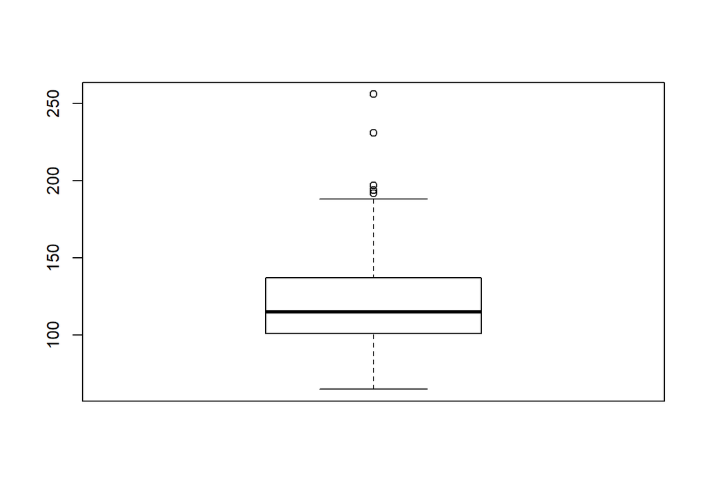

```r
#Loss Variable

boxplot(data$Loss) #Contains Outlier
```

```r
boxplot.stats(data$Loss) #Contains Outlier values in Out
```

```
## $stats
## [1]  65 101 115 137 188
##
## $n
## [1] 204
##
## $conf
## [1] 111.0176 118.9824
##
## $out
## [1] 192 231 192 194 194 197 197 256
```

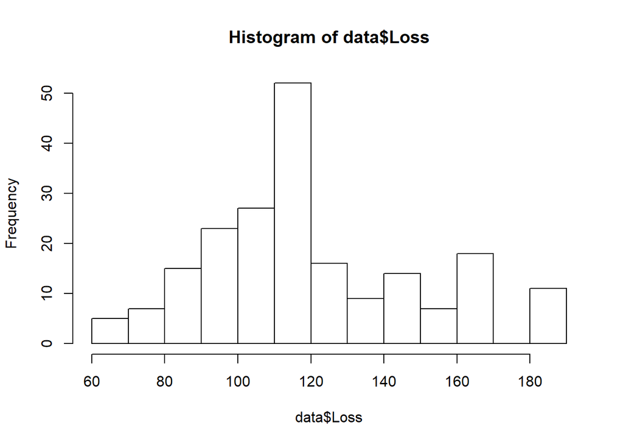

```r
data$Loss <- replace(data$Loss, data$Loss >= 189, 188)# Outlier Treated
hist(data$Loss)
```

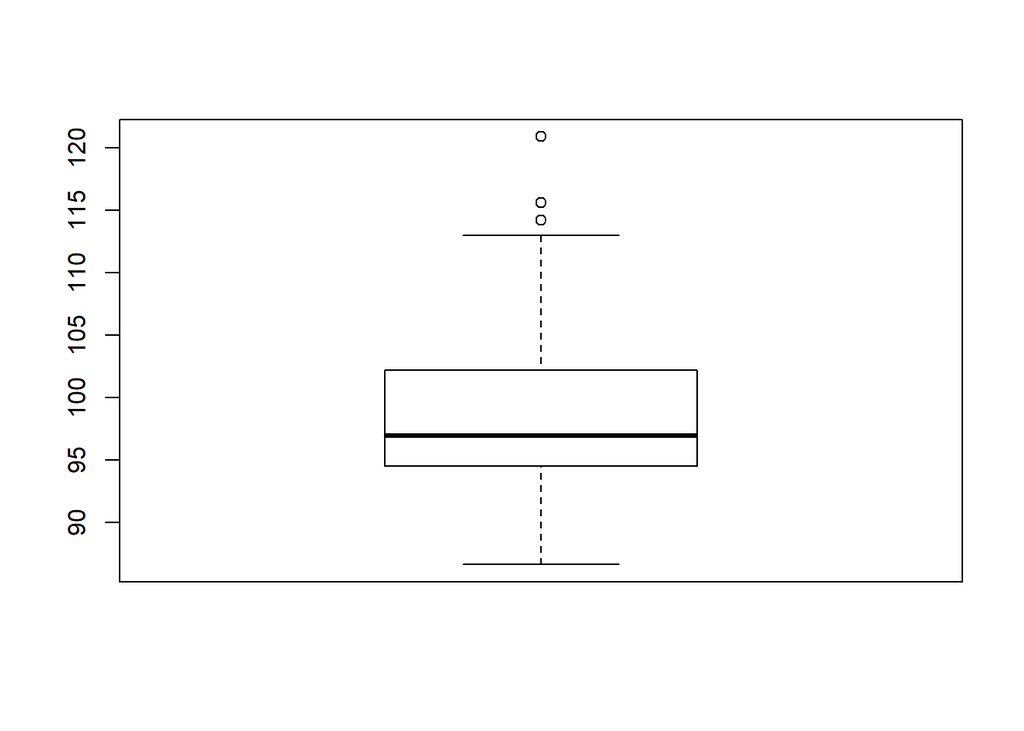

```r
#Wheel Base Variable
boxplot(data$WheelBase)
```

```r
boxplot.stats(data$WheelBase)
```

```
## $stats
## [1]  86.60  94.50  96.95 102.20 113.00
##
## $n
## [1] 204
##
## $conf
## [1] 96.09821 97.80179
##
## $out
## [1] 115.6 115.6 120.9 114.2 114.2 114.2 114.2
```

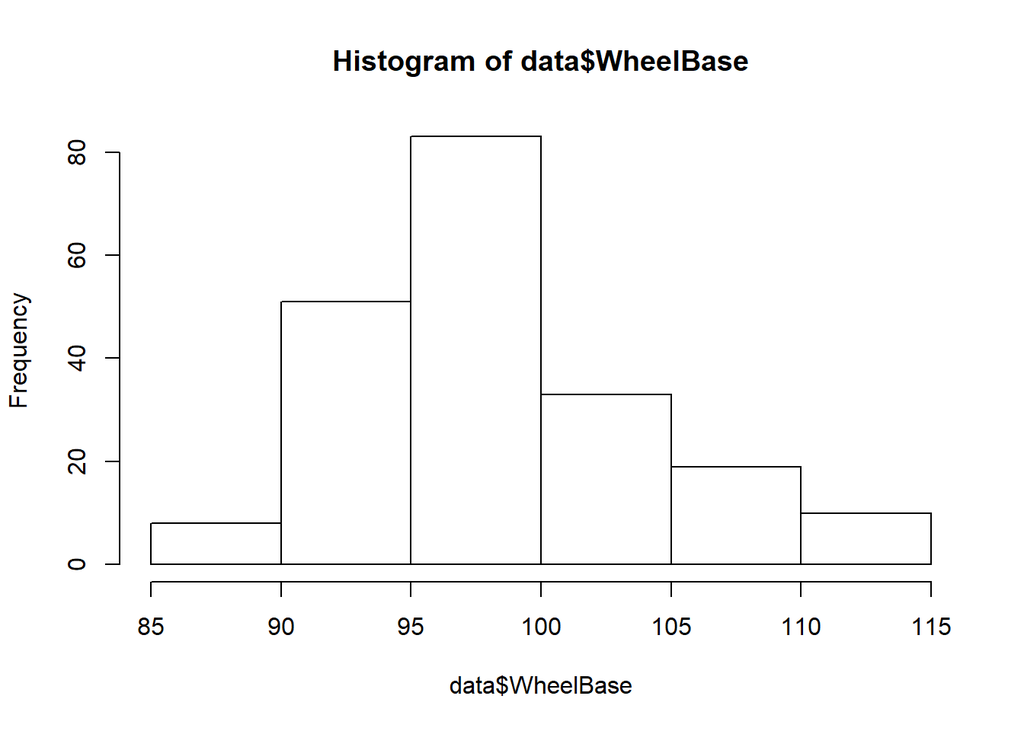

```r
data$WheelBase <- replace(data$WheelBase, data$WheelBase >= 114, 113)
hist(data$WheelBase)
```

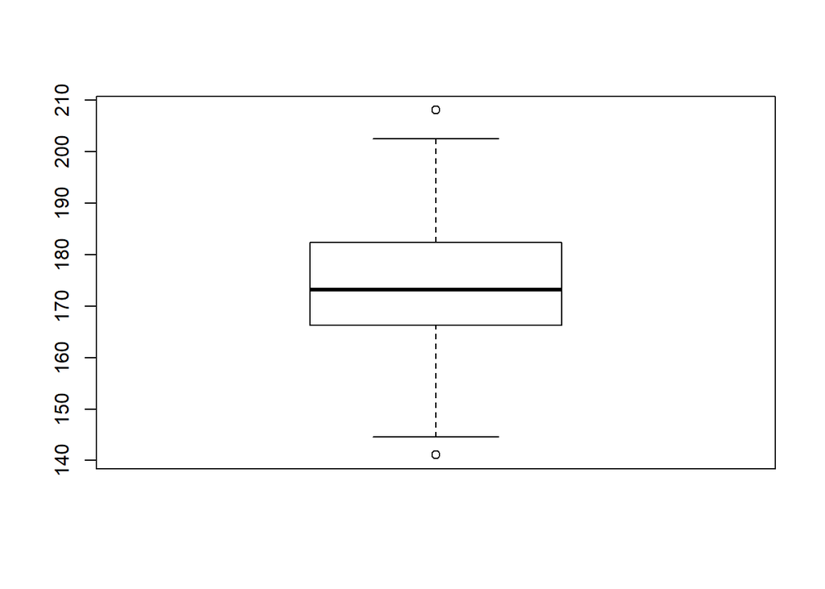

```r
#Length Variable
boxplot(data$Length)
```

```r
boxplot.stats((data$Length))
```

```
## $stats
## [1] 144.6 166.3 173.2 182.4 202.6
##
## $n
## [1] 204
##
## $conf
## [1] 171.419 174.981
##
## $out
## [1] 208.1 141.1
```

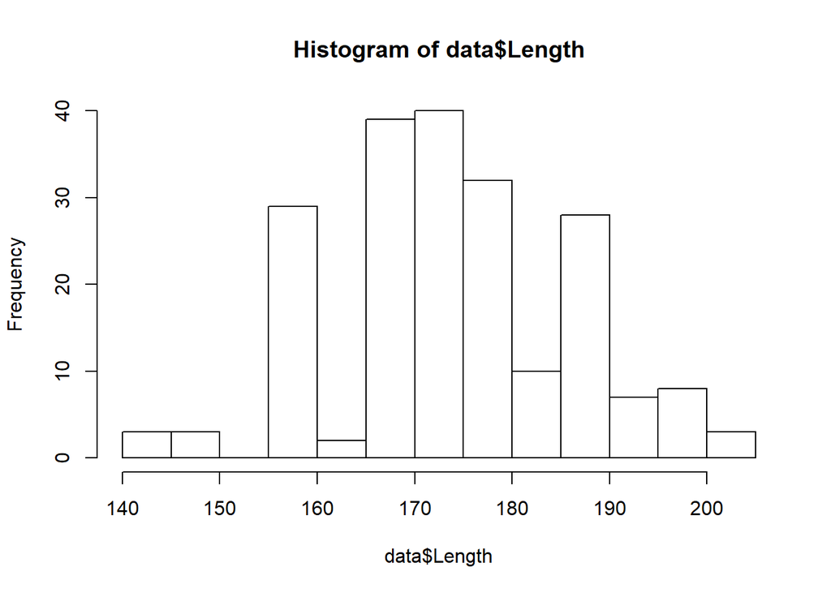

```r
data$Length <- replace(data$Length, data$Length >= 203, 202.6)
data$Length <- replace(data$Length, data$Length < 142, 144.6)
hist(data$Length)
```

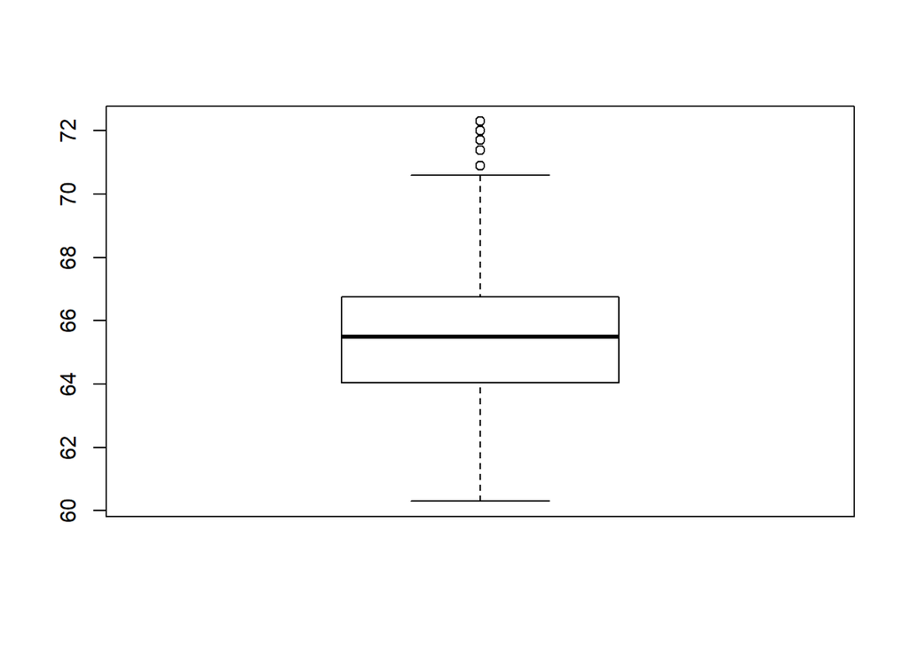

```r
#Width Variable
boxplot(data$Width)
```

```r
boxplot.stats(data$Width)
```

```
## $stats
## [1] 60.30 64.05 65.50 66.75 70.60
##
## $n
## [1] 204
##
## $conf
## [1] 65.20132 65.79868
##
## $out
## [1] 71.7 71.7 70.9 71.7 71.4 71.4 71.4 72.0 72.3
```

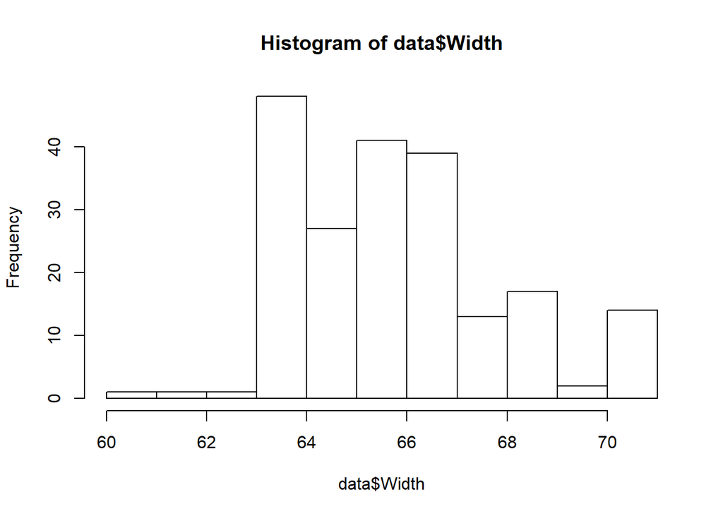

```r
data$Width <- replace(data$Width, data$Width >= 70.70, 70.60)
hist(data$Width)
```

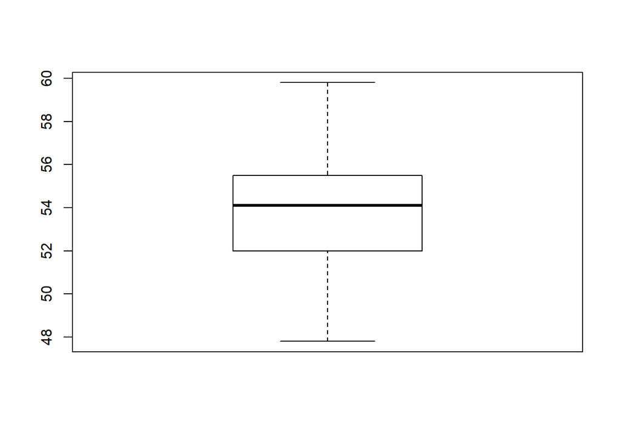

```r
#Height Variable
boxplot(data$Height)
```

```r
boxplot.stats(data$Height) #NO Outlier found
```

```
## $stats
## [1] 47.8 52.0 54.1 55.5 59.8
##
## $n
## [1] 204
##
## $conf
## [1] 53.71282 54.48718
##
## $out
## numeric(0)
```

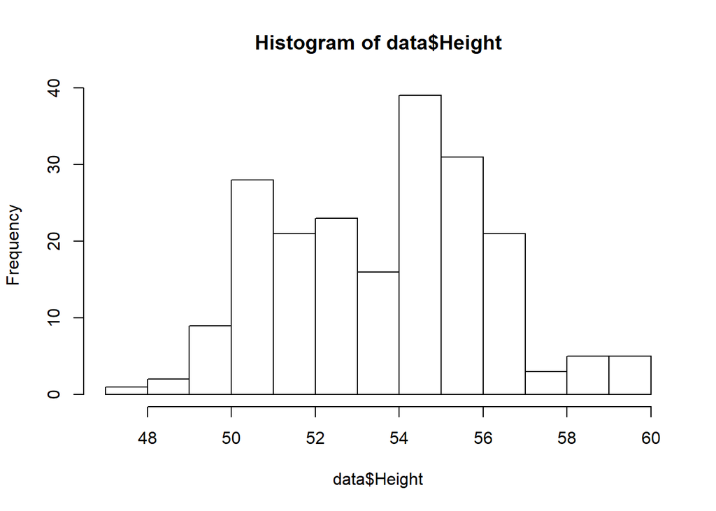

```r
hist(data$Height)
```

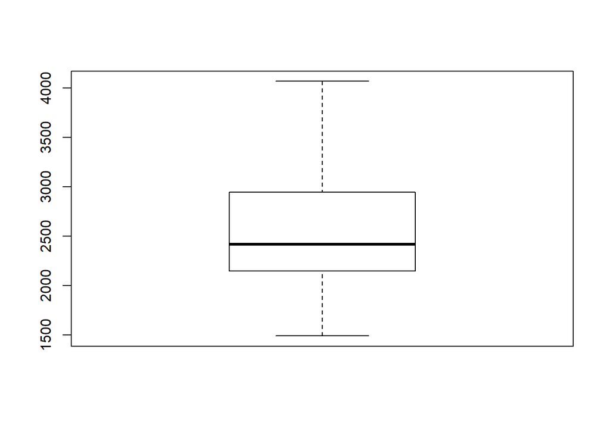

```r
#Curb Weight
boxplot(data$CurbWeight)
```

```r
boxplot.stats(data$CurbWeight)#No Outlier Found
```

```
## $stats
## [1] 1488.0 2145.0 2414.0 2943.5 4066.0
##
## $n
## [1] 204
##
## $conf
## [1] 2325.668 2502.332
##
## $out
## integer(0)
```

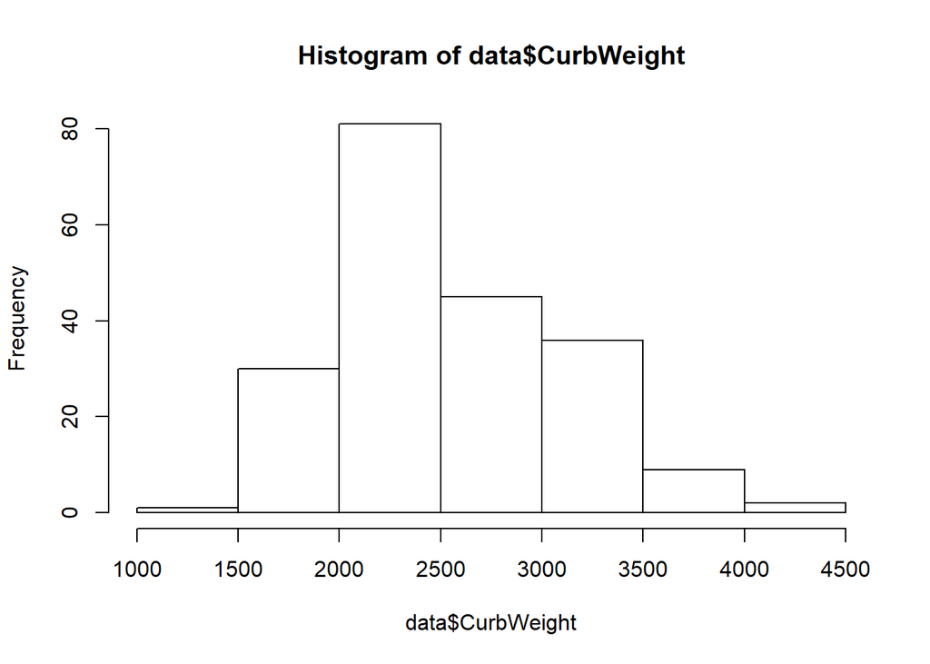

```r
hist(data$CurbWeight)
```

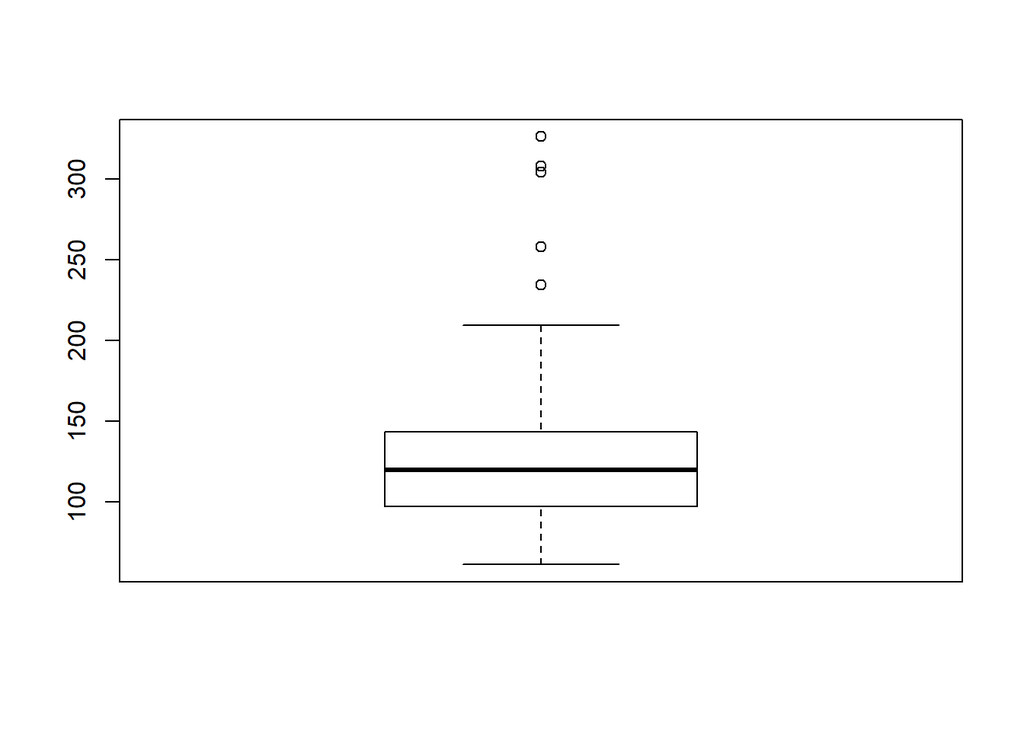

```r
#Engine Size
boxplot(data$EngineSize)
```

```r
boxplot.stats(data$EngineSize)
```

```
## $stats
## [1]  61.0  97.0 119.5 143.0 209.0
##
## $n
## [1] 204
##
## $conf
## [1] 114.4114 124.5886
##
## $out
## [1] 234 258 258 326 308 304 234
```

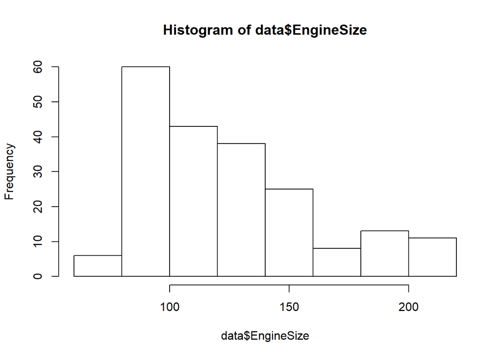

```r
data$EngineSize <- replace(data$EngineSize, data$EngineSize >= 210, 209)
hist(data$EngineSize)
```

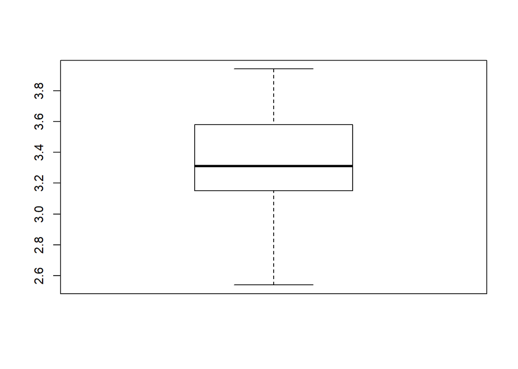

```r
#Bore Size
boxplot(data$Bore)
```

```r
boxplot.stats(data$Bore) #NO outlier Found
```

```
## $stats
## [1] 2.54 3.15 3.31 3.58 3.94
##
## $n
## [1] 204
##
## $conf
## [1] 3.262432 3.357568
##
## $out
## numeric(0)
```

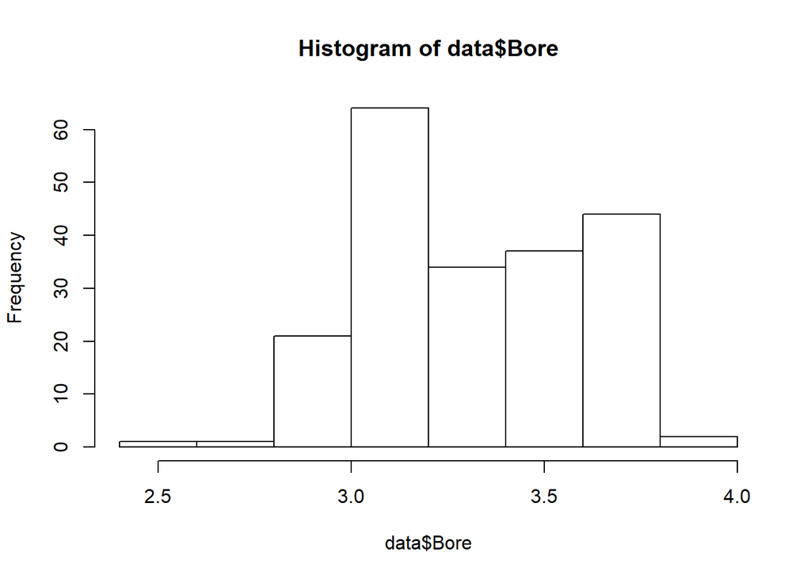

```r
hist(data$Bore)
```

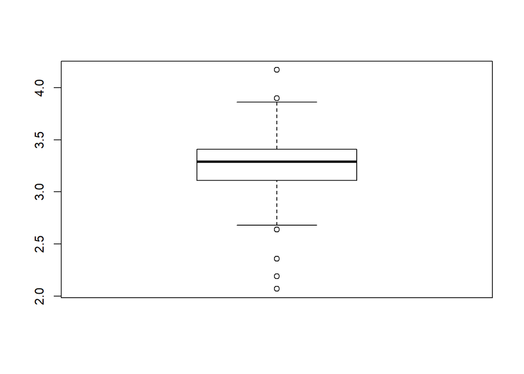

```r
#Stroke
boxplot(data$Stroke)
```

```r
boxplot.stats(data$Stroke)
```

```
## $stats
## [1] 2.68 3.11 3.29 3.41 3.86
##
## $n
## [1] 204
##
## $conf
## [1] 3.256813 3.323187
##
## $out
##  [1] 4.17 4.17 2.19 2.19 3.90 2.64 2.64 2.64 2.64 2.64 2.64 2.64 2.64 2.64
## [15] 3.90 2.36 2.64 2.64 3.90 2.07
```

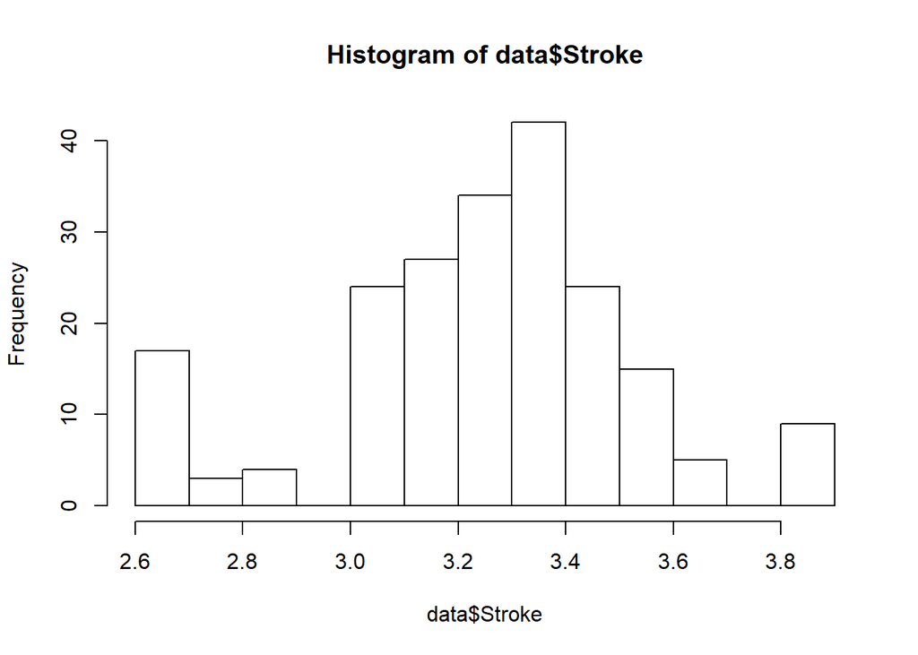

```r
data$Stroke <- replace(data$Stroke, data$Stroke <= 2.67, 2.68)
data$Stroke <- replace(data$Stroke, data$Stroke >= 3.9, 3.86)
hist(data$Stroke)
```

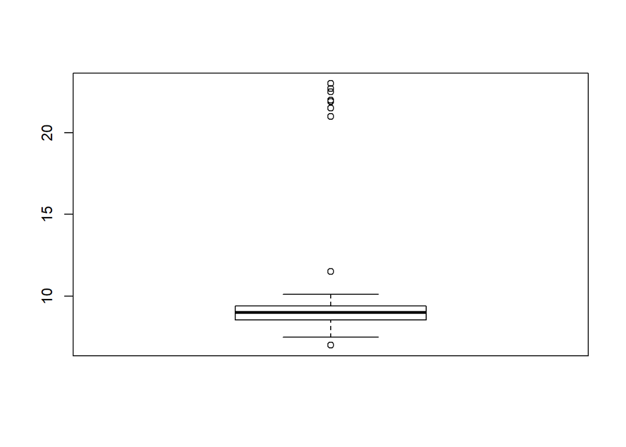

```r
#Compression Ratio
boxplot(data$CompressionRatio)
```

```r
boxplot.stats(data$CompressionRatio)
```

```
## $stats
## [1]  7.50  8.55  9.00  9.40 10.10
##
## $n
## [1] 204
##
## $conf
## [1] 8.905971 9.094029
##
## $out
##  [1] 21.5 21.5 21.5 22.5 23.0  7.0 11.5 22.7 22.0 21.5 21.0 21.0 21.0 21.0
## [15] 21.0  7.0 22.5 22.5 23.0 21.9 23.0 23.0 23.0  7.0  7.0  7.0  7.0  7.0
```

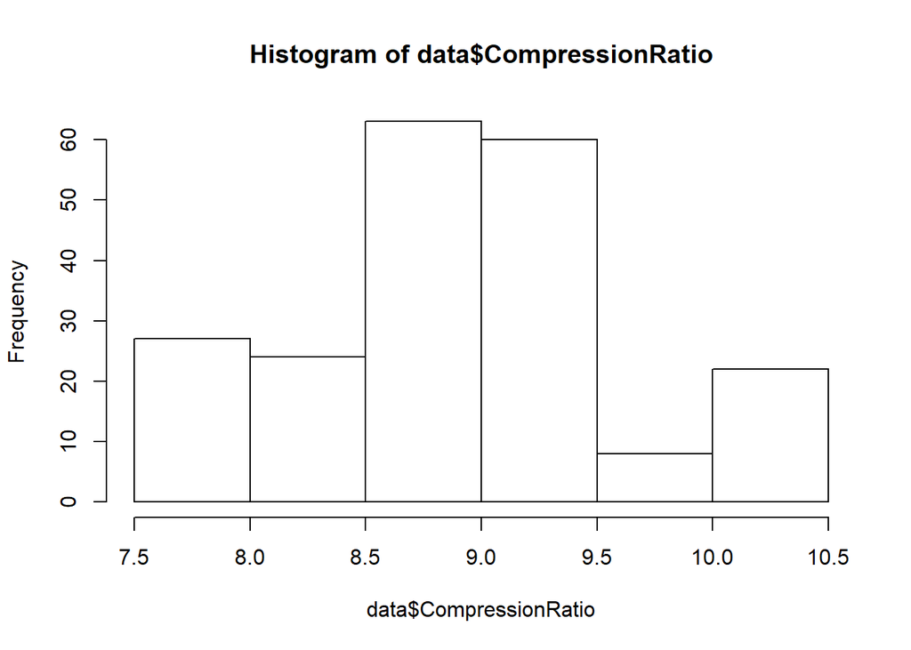

```r
data$CompressionRatio <- replace(data$CompressionRatio, data$CompressionRatio >= 10.11, 10.10)
data$CompressionRatio <- replace(data$CompressionRatio, data$CompressionRatio <= 7.49, 7.50)
hist(data$CompressionRatio)
```

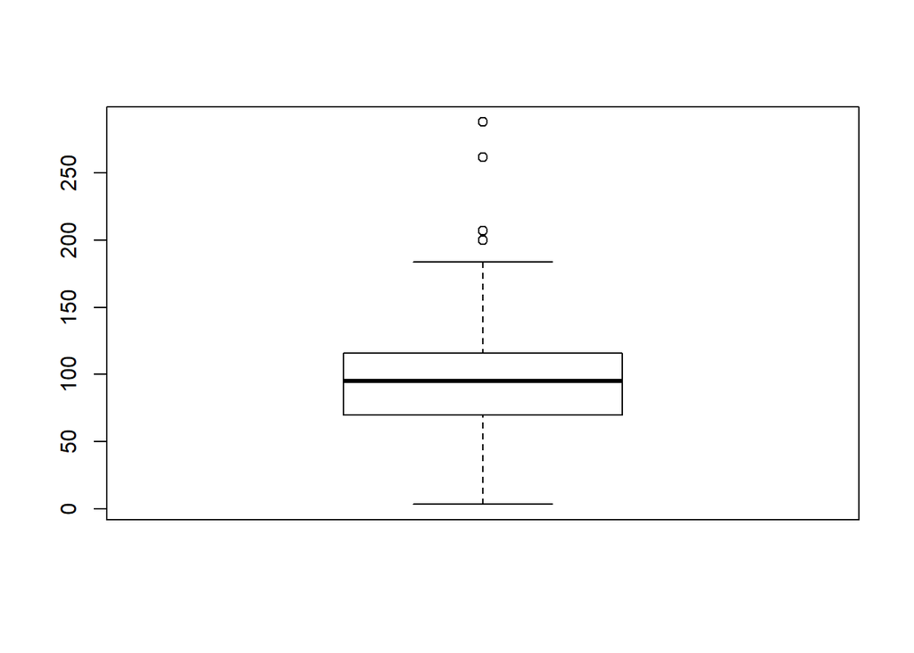

```r
#Horse Power
boxplot(data$HorsePower)
```

```r
boxplot.stats(data$HorsePower)
```

```
## $stats
## [1]   3.29  70.00  95.00 116.00 184.00
##
## $n
## [1] 204
##
## $conf
## [1]  89.91138 100.08862
##
## $out
## [1] 262 288 200 207 207 207
```

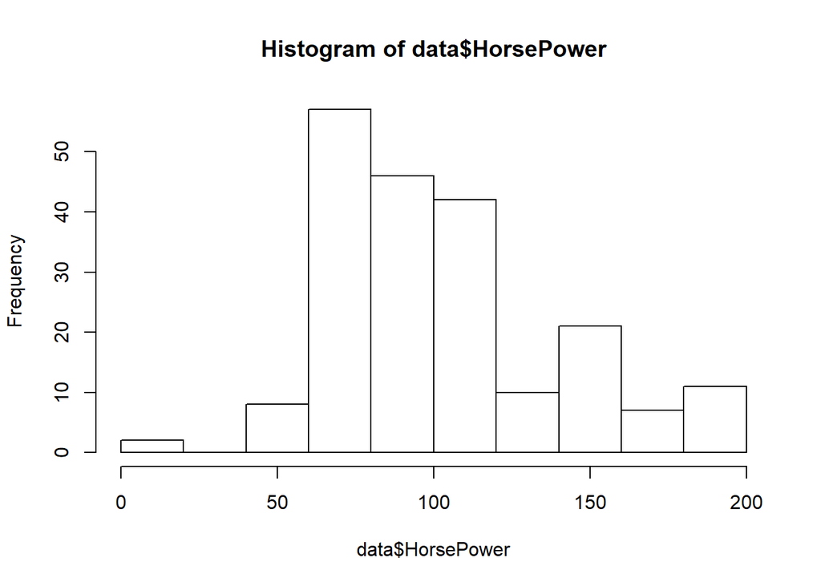

```r
data$HorsePower <- replace(data$HorsePower, data$HorsePower >= 184.01, 184.00)
hist(data$HorsePower)
```

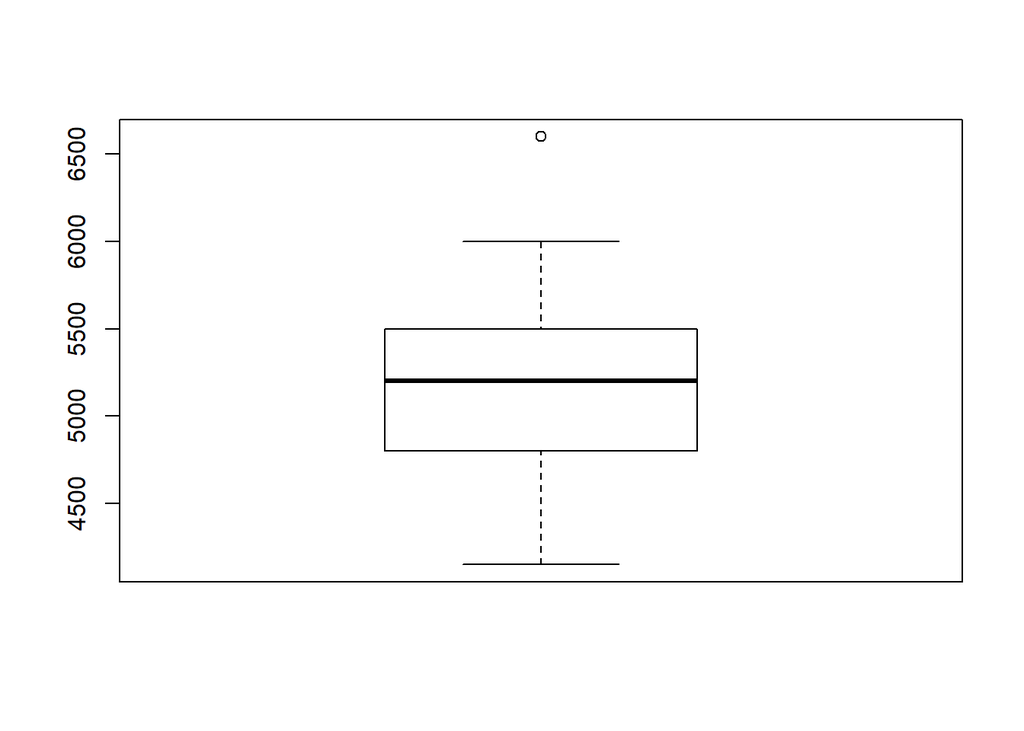

```r
#Peak RPM
boxplot(data$PeakRPM)
```

```r
boxplot.stats(data$PeakRPM)
```

```
## $stats
## [1] 4150 4800 5200 5500 6000
##
## $n
## [1] 204
##
## $conf
## [1] 5122.565 5277.435
##
## $out
## [1] 6600 6600
```

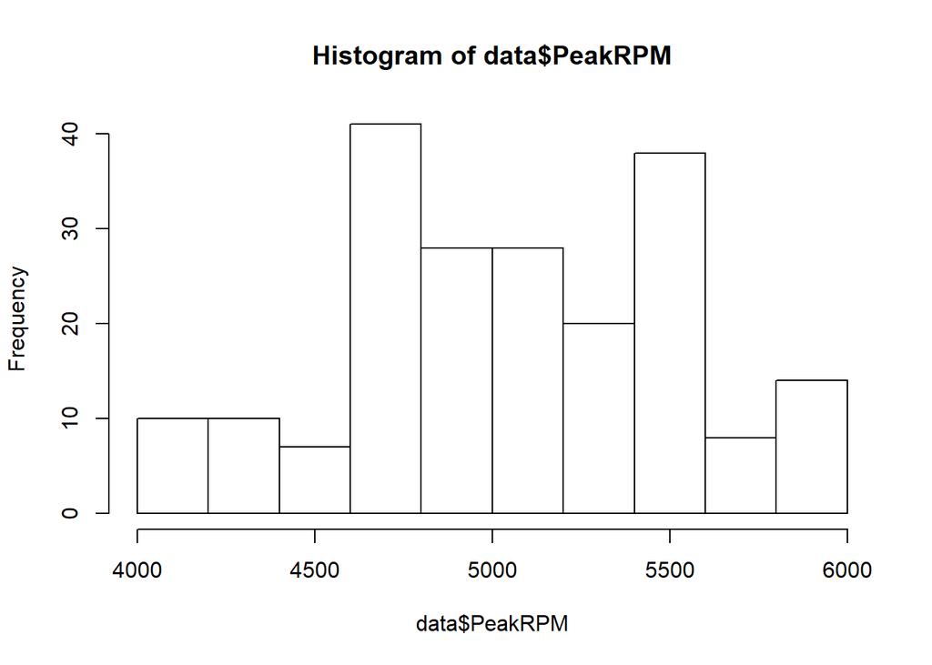

```r
data$PeakRPM <- replace(data$PeakRPM, data$PeakRPM >= 6001, 6000)
hist(data$PeakRPM)
```

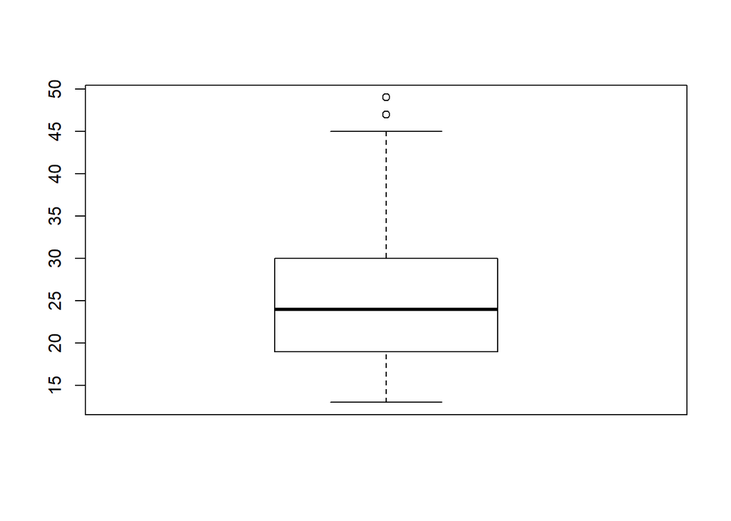

```r
#City MPG
boxplot(data$CityMPG)
```

```r
boxplot.stats(data$CityMPG)
```

```
## $stats
## [1] 13 19 24 30 45
##
## $n
## [1] 204
##
## $conf
## [1] 22.78316 25.21684
##
## $out
## [1] 47 49
```

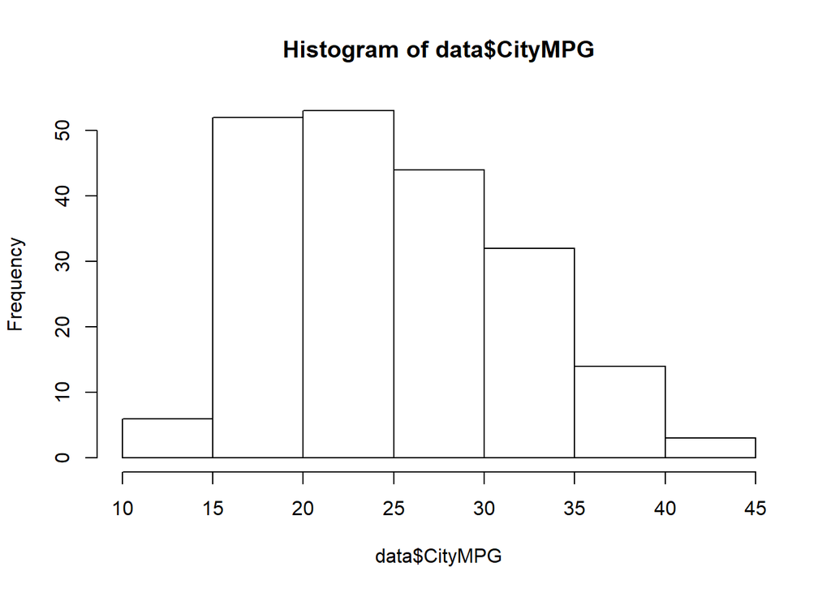

```r
data$CityMPG <- replace(data$CityMPG, data$CityMPG >= 46, 45)
hist(data$CityMPG)
```

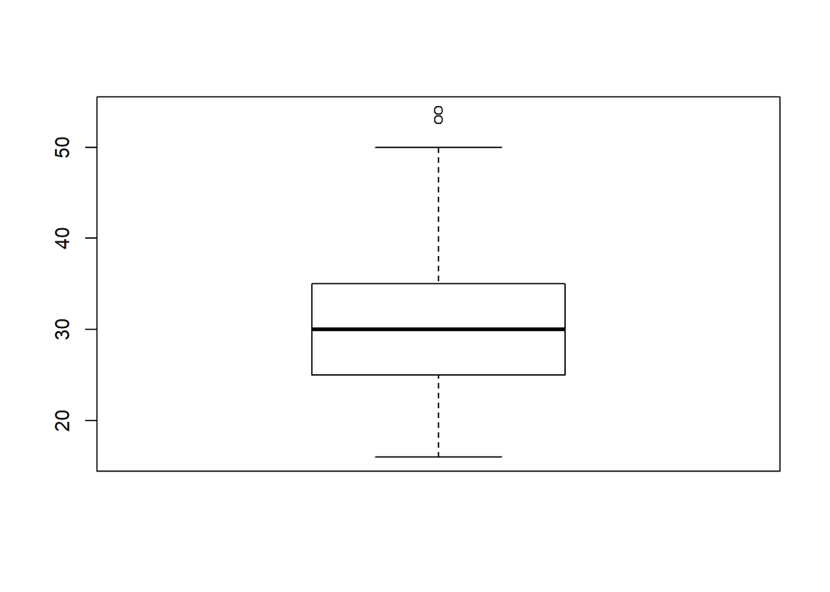

```r
#Highway MPG
data$HighwayMPG <- dataset$HighwayMPG
boxplot(data$HighwayMPG)
```

```r
boxplot.stats(data$HighwayMPG)
```

```
## $stats
## [1] 16 25 30 35 50
##
## $n
## [1] 204
##
## $conf
## [1] 28.89378 31.10622
##
## $out
## [1] 53 54
```

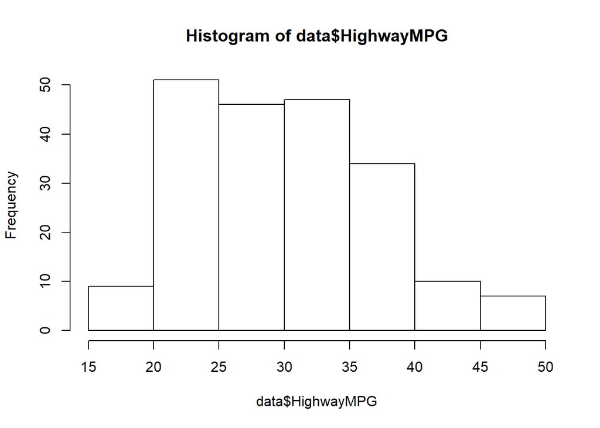

```r
data$HighwayMPG <- replace(data$HighwayMPG, data$HighwayMPG >= 51, 50)
hist(data$HighwayMPG)
```

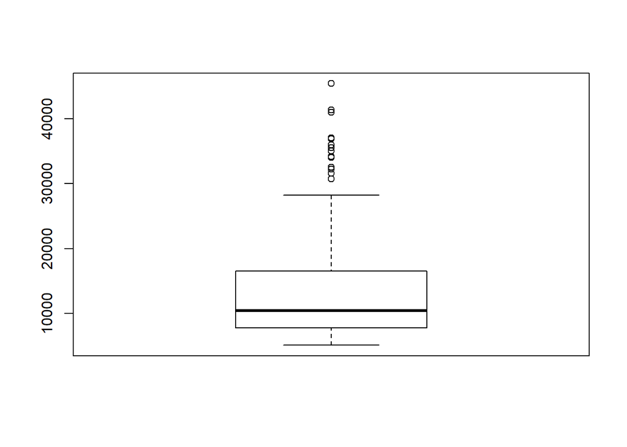

```r
#Price
boxplot(data$Price)
```

```r
boxplot.stats((data$Price))
```

```
## $stats
## [1]  5118.0  7781.5 10470.0 16500.0 28248.0
##
## $n
## [1] 204
##
## $conf
## [1]  9505.541 11434.459
##
## $out
##  [1] 31600 34184 30760 41315 36880 32250 35550 36000 40960 45400 35056
## [12] 32528 34028 37028
```

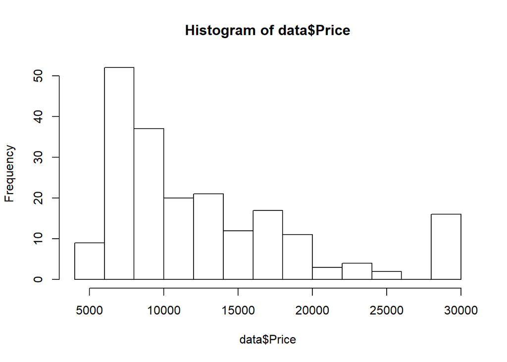

```r
data$Price <- replace(data$Price, data$Price >= 29000.0, 28248.0)
hist(data$Price)
```

## Univariant Analysis

To Understand the missing values, mean, median, outliers univariant analysis is useful.

```r
#install.packages("pastecs")
#install.packages("psych")
library(psych)
library(pastecs)
```

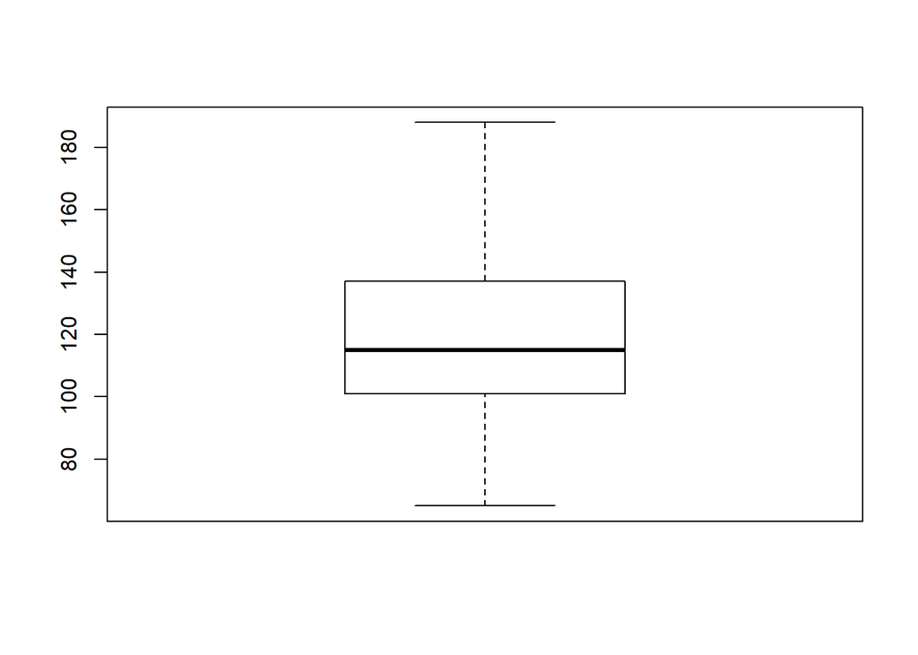

```r
#Loss
boxplot(data$Loss) #Outlier Present
```

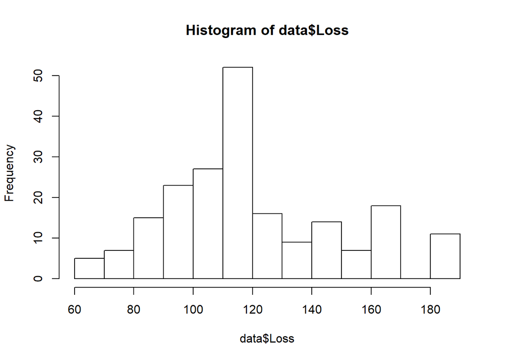

```r
hist(data$Loss) #Right Sweked
```

```r
describe(data$Loss)
```

```
##    vars   n   mean    sd median trimmed   mad min max range skew kurtosis
## X1    1 204 119.96 29.71    115  118.29 28.91  65 188   123 0.54    -0.29
##      se
## X1 2.08
```

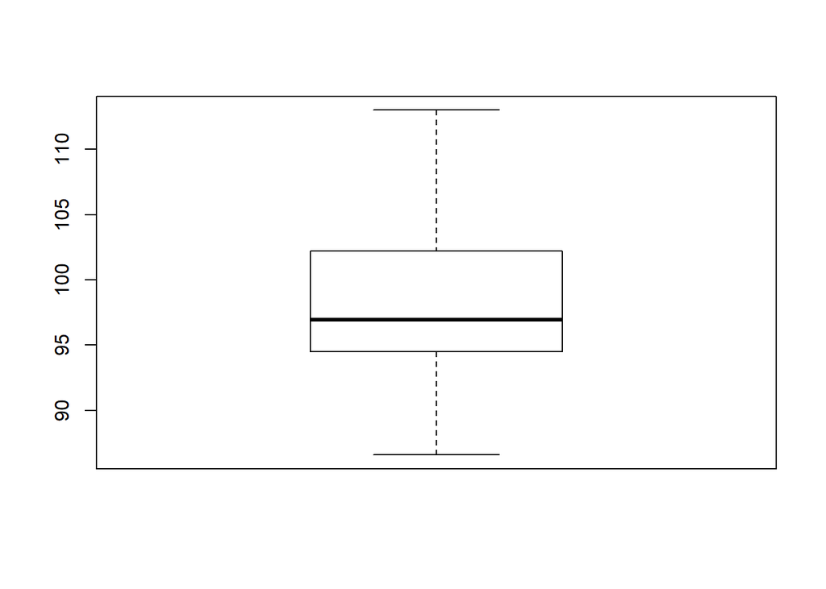

```r
#WheelBase
boxplot(data$WheelBase) #Outlier Present
```

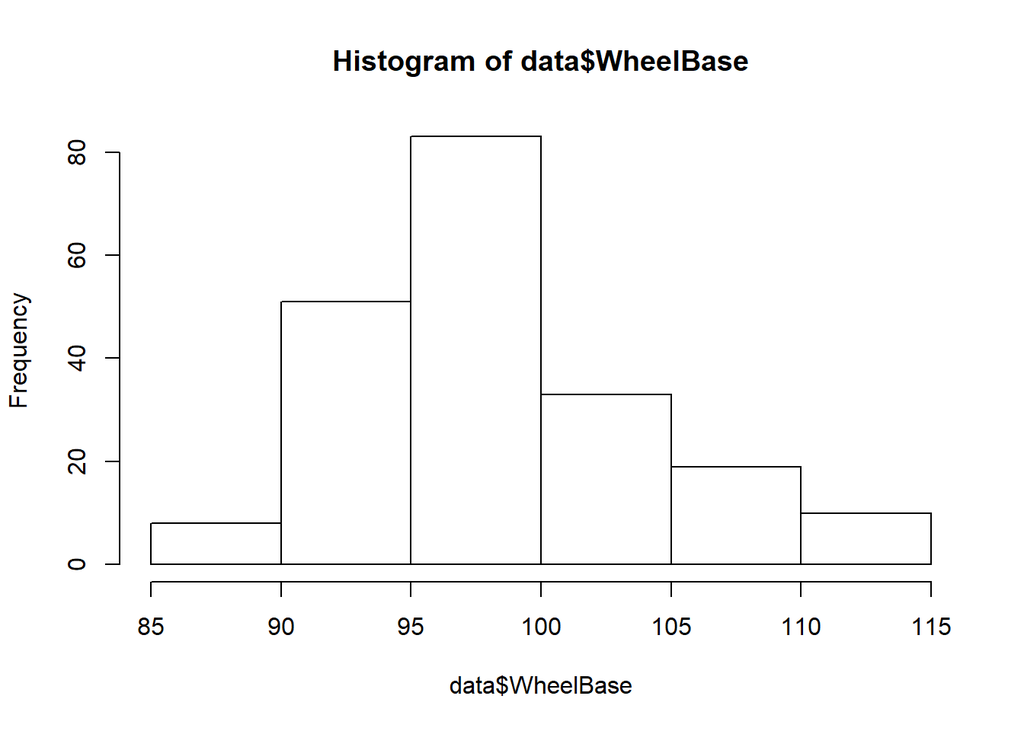

```r
hist(data$WheelBase) #Right Sweked
```

```r
describe(data$WheelBase)
```

```
##    vars   n  mean   sd median trimmed  mad  min max range skew kurtosis
## X1    1 204 98.64 5.78  96.95   98.05 3.85 86.6 113  26.4 0.85     0.22
##     se
## X1 0.4
```

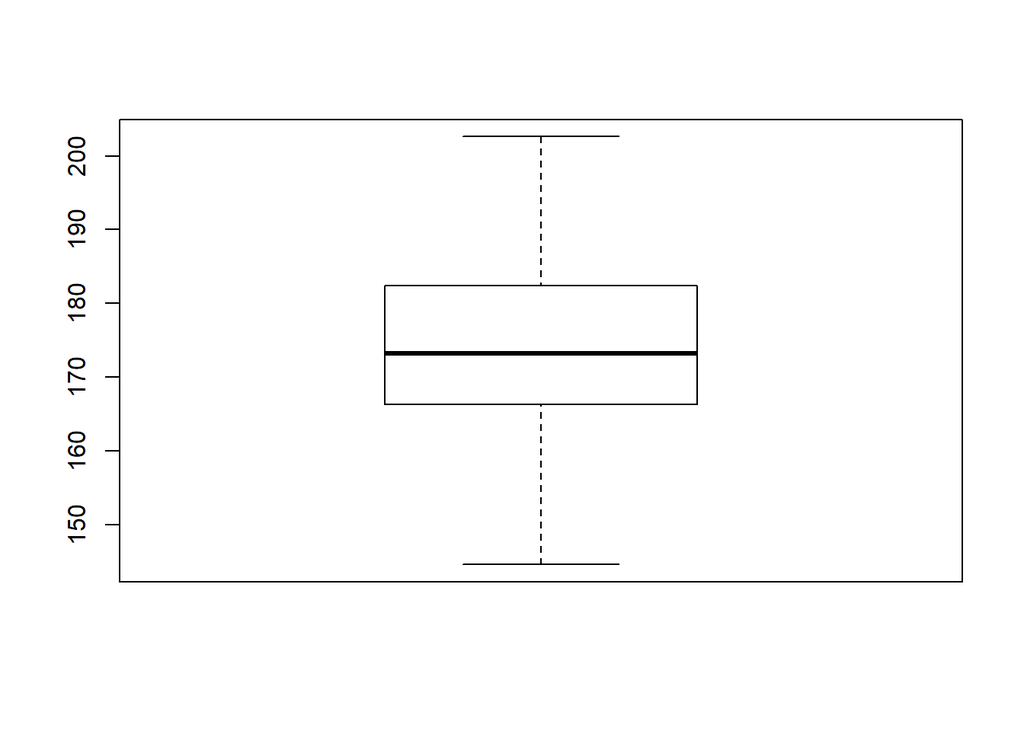

```r
#Length
boxplot(data$Length) #Outlier Present
```

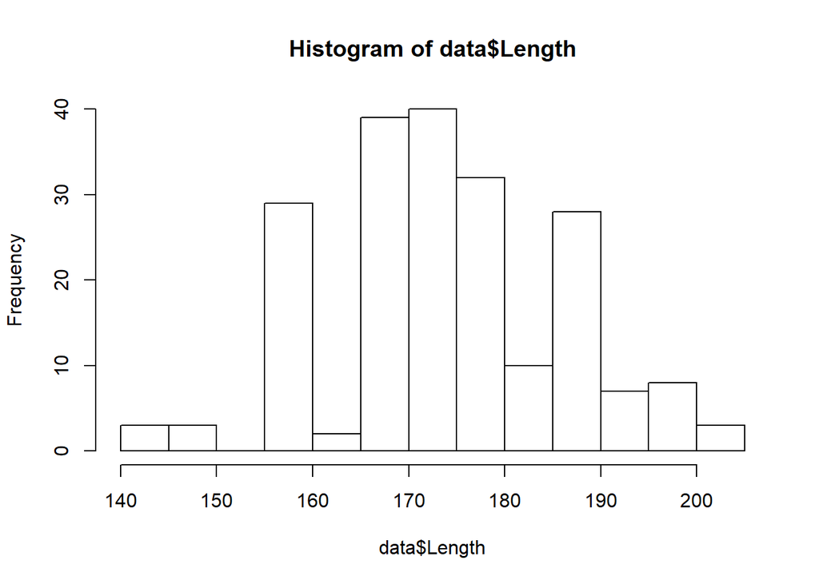

```r
hist(data$Length) #Perfect
```

```r
describe(data$Length)
```

```
##    vars   n   mean    sd median trimmed   mad   min   max range skew
## X1    1 204 173.97 12.21  173.2  173.69 10.23 144.6 202.6    58 0.15
##    kurtosis   se
## X1    -0.25 0.85
```

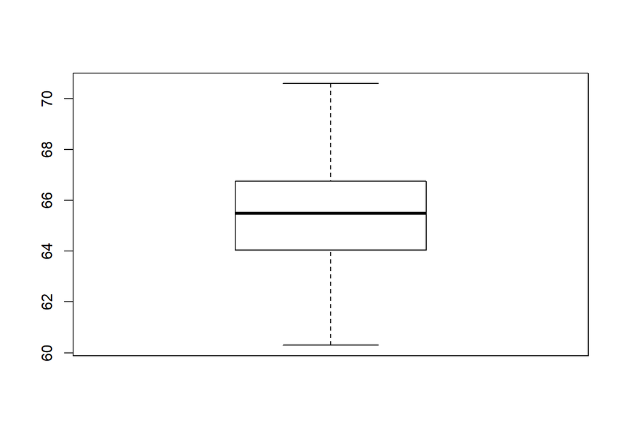

```r
#Width
boxplot(data$Width)#Outlier Present
```

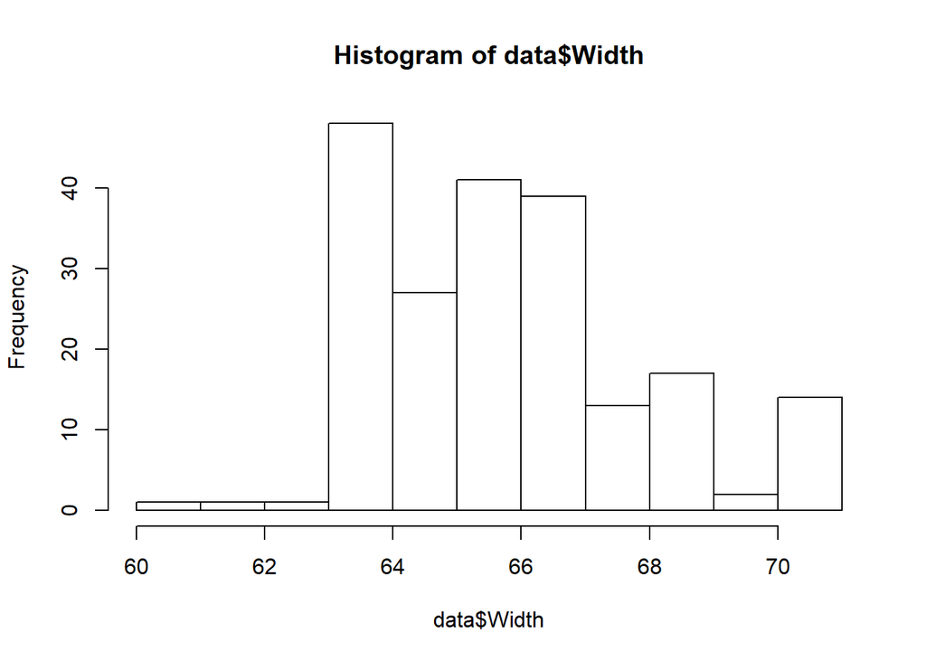

```r
hist(data$Width) #Right Skew
```

```r
describe(data$Width)
```

```
##    vars   n  mean   sd median trimmed  mad  min  max range skew kurtosis
## X1    1 204 65.86 2.04   65.5   65.65 2.08 60.3 70.6  10.3 0.68     0.01
##      se
## X1 0.14
```

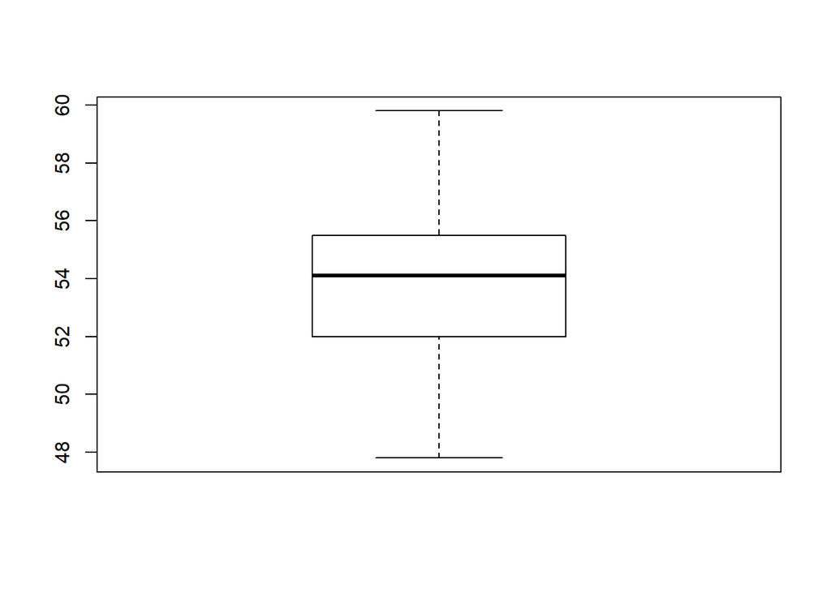

```r
#Height
boxplot(data$Height) #No Outlier
```

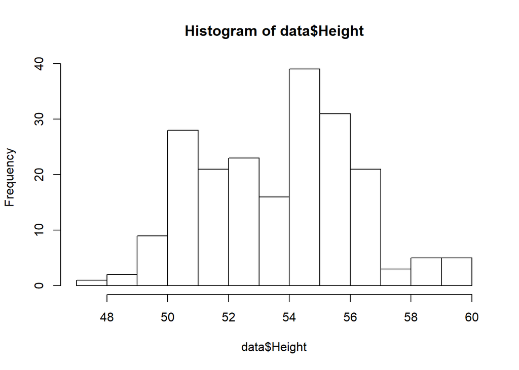

```r
hist(data$Height) #Perfect
```

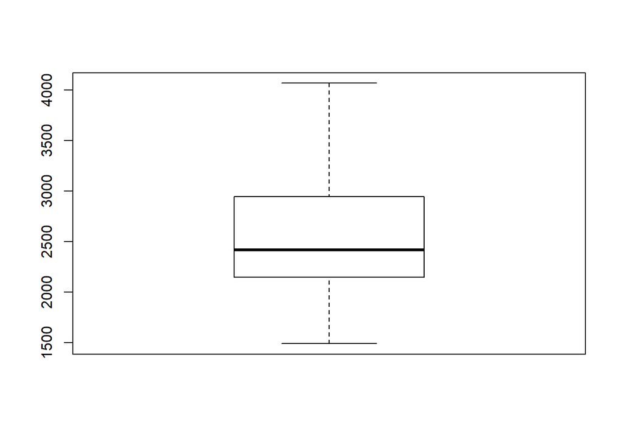

```r
#Curb Weight
boxplot(data$CurbWeight) #No Outlier
```

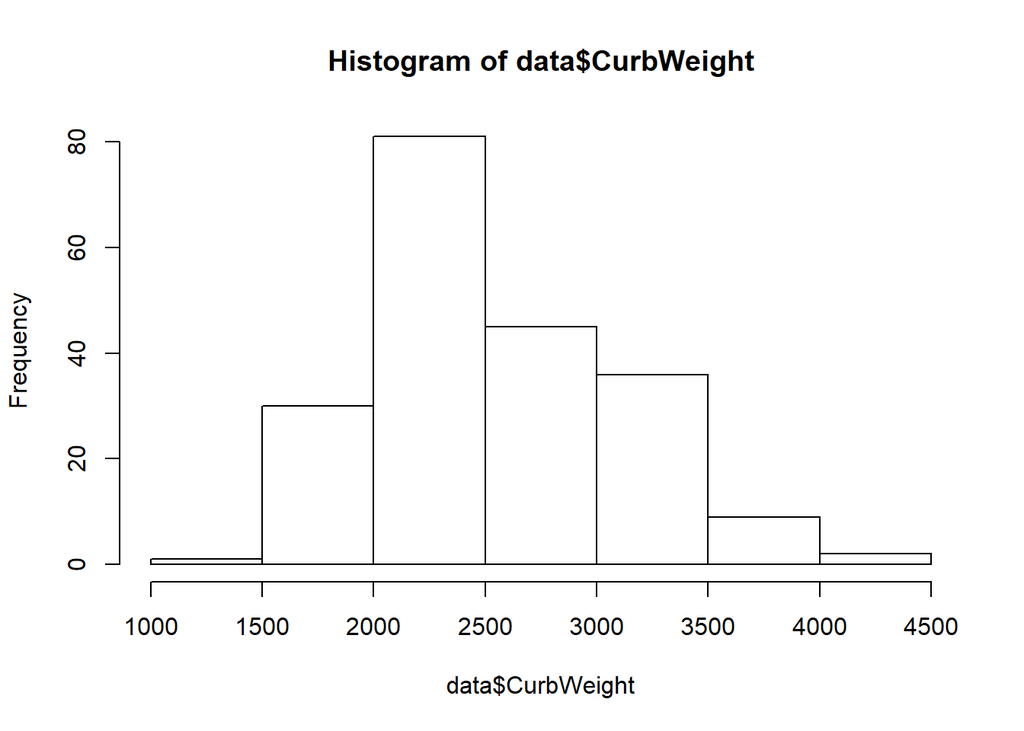

```r
hist(data$CurbWeight) #Right Skew
```

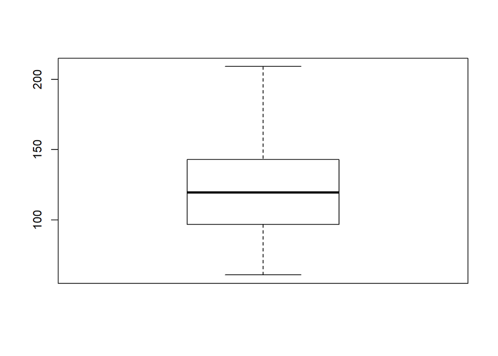

```r
#Engine Size
boxplot(data$EngineSize) #Outlier Present
```

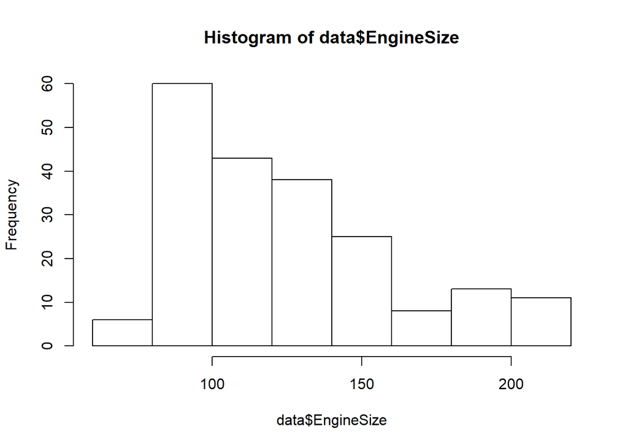

```r
hist(data$EngineSize) #Right Skew
```

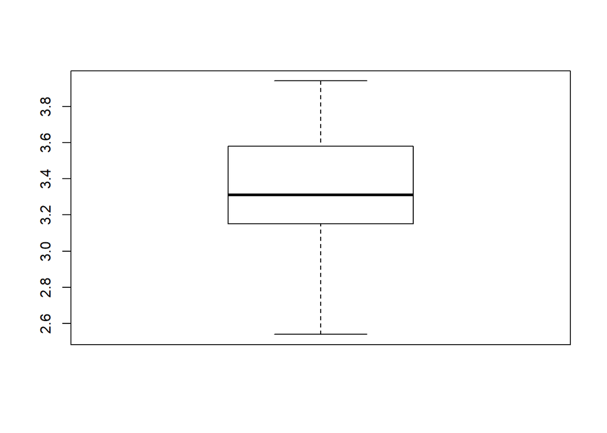

```r
#Bore
boxplot(data$Bore) #No Outlier
```

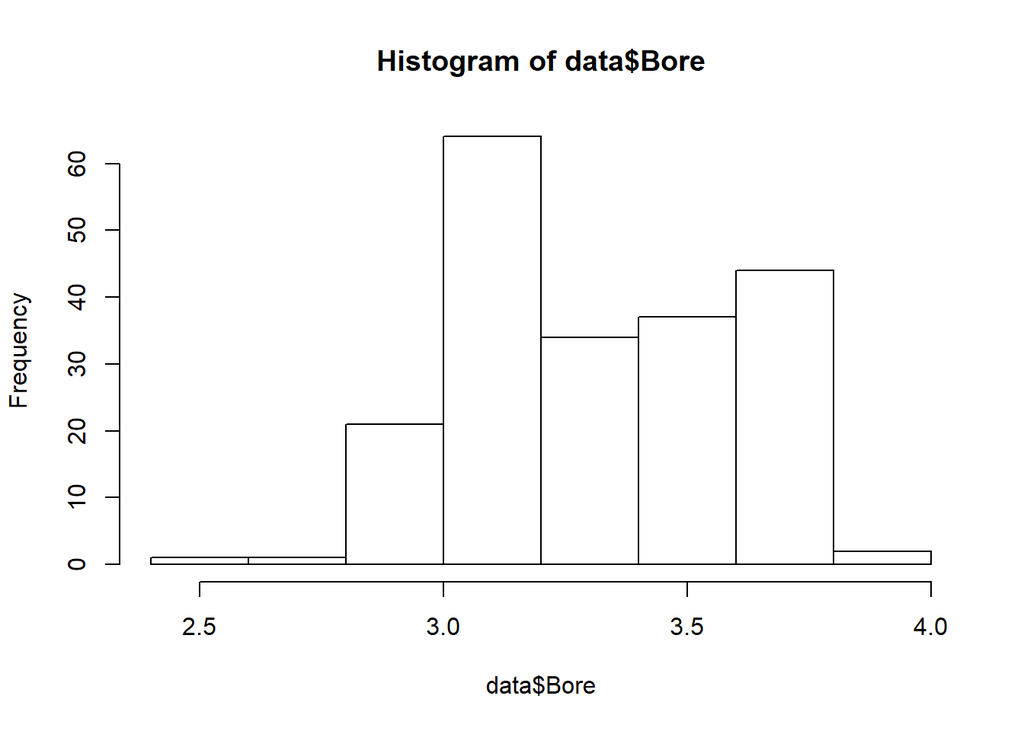

```r
hist(data$Bore) #Left Skew
```

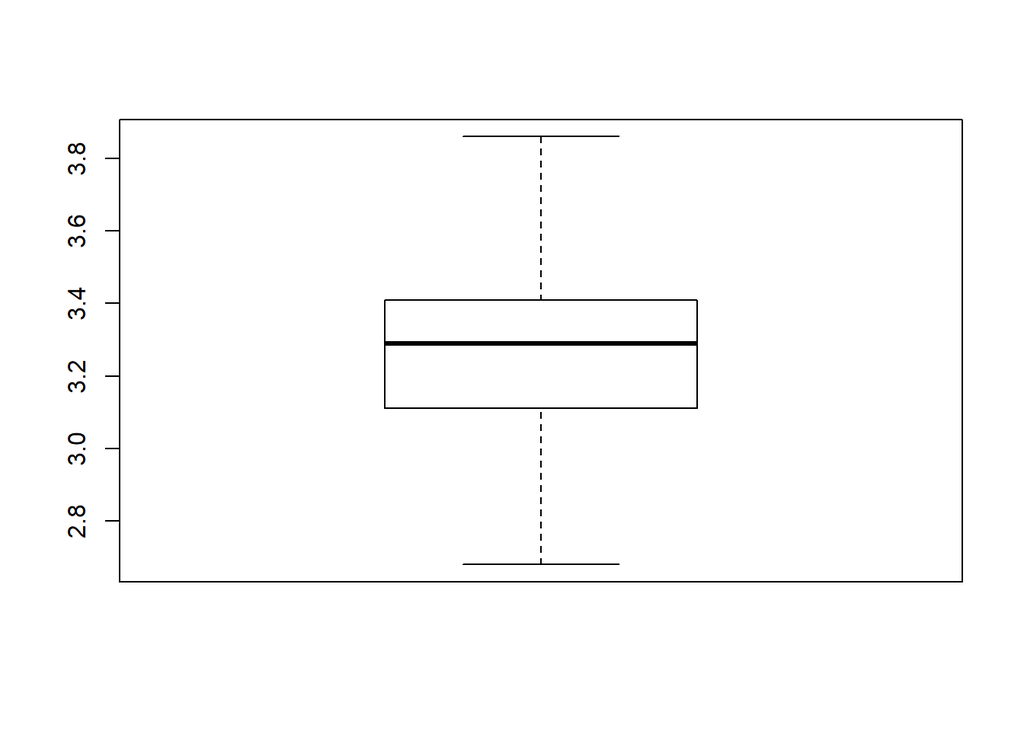

```r
#Stroke
boxplot(data$Stroke) #Outlier Present
```

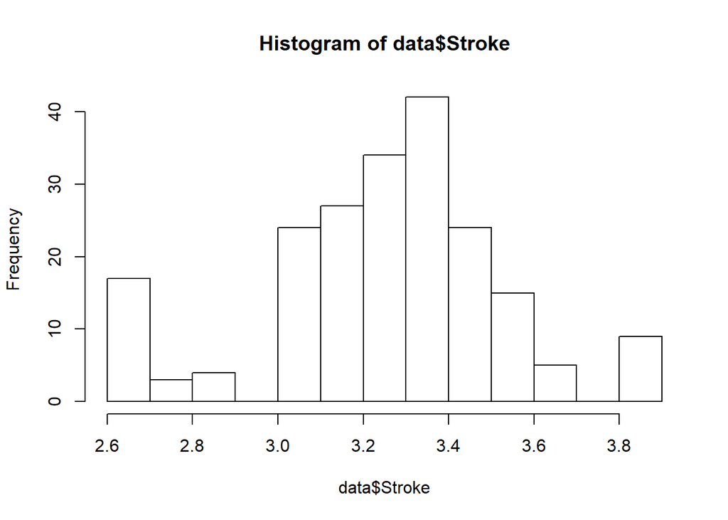

```r
hist(data$Stroke) #Left Skew
```

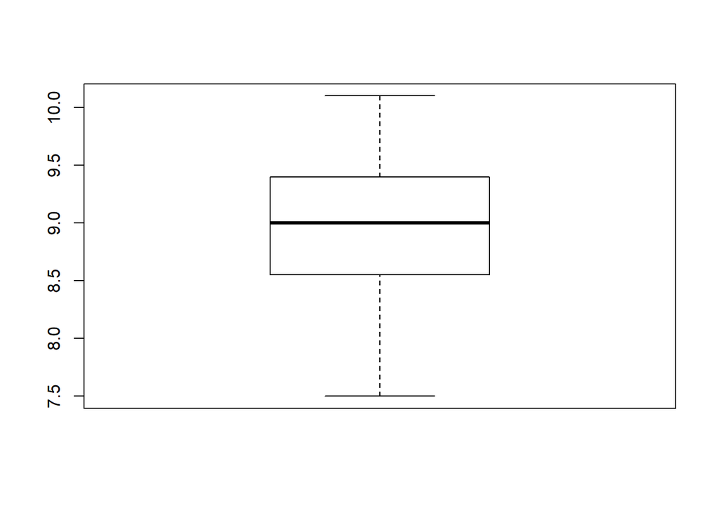

```r
#Compression Ratio
boxplot(data$CompressionRatio)  #Outlier Present
```

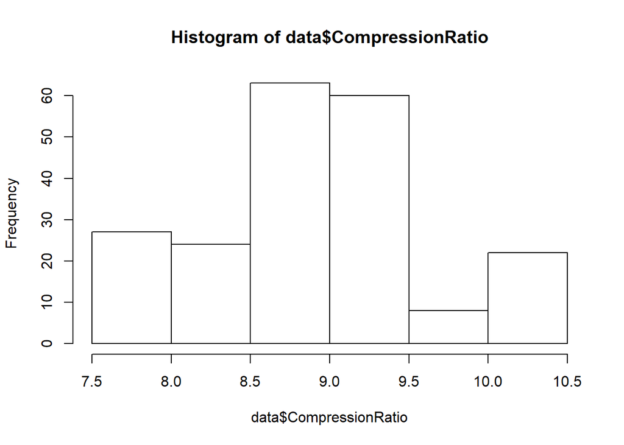

```r
hist(data$CompressionRatio) #Right Skew
```

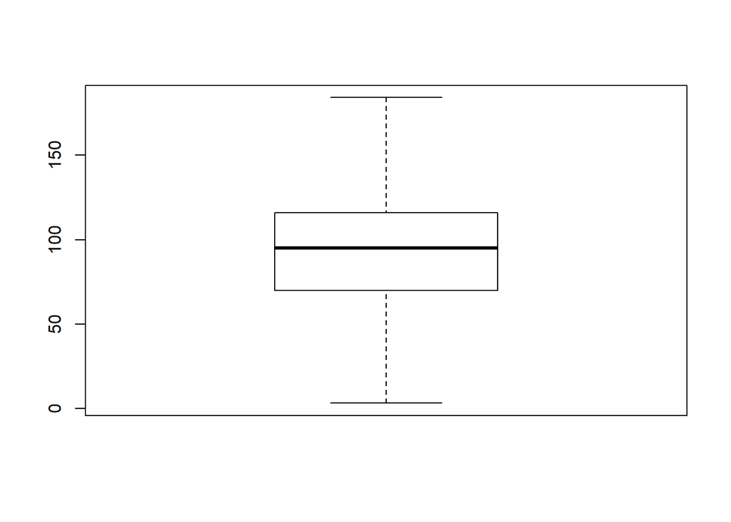

```r
#Horse Power
boxplot(data$HorsePower) #Outlier Present
```

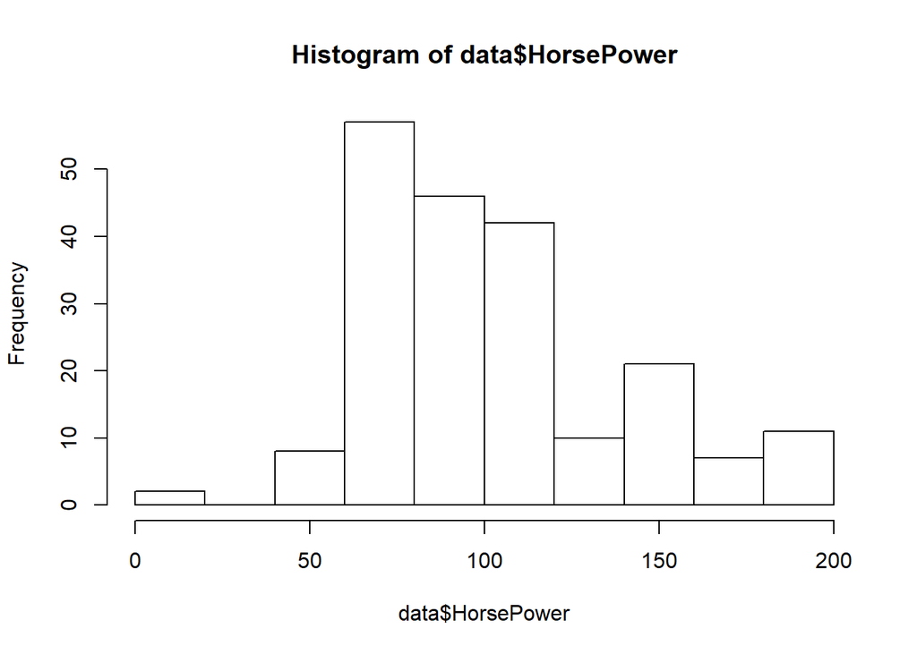

```r
hist(data$HorsePower) #Right Skew
```

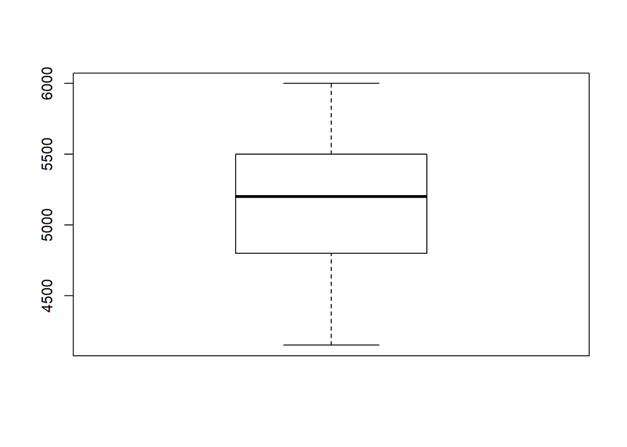

```r
#PeakRPM
boxplot(data$PeakRPM) #Outlier Present
```

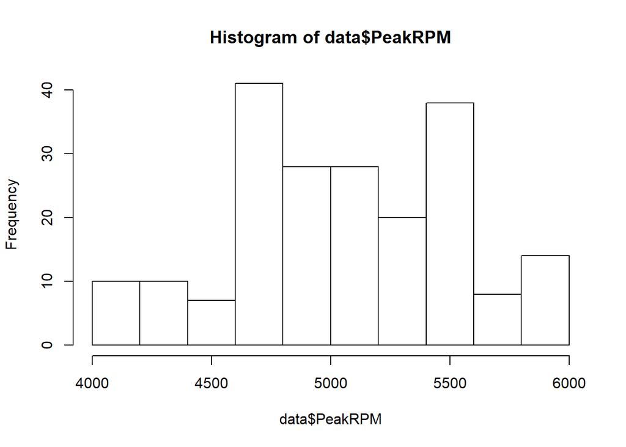

```r
hist(data$PeakRPM) #Right skew
```

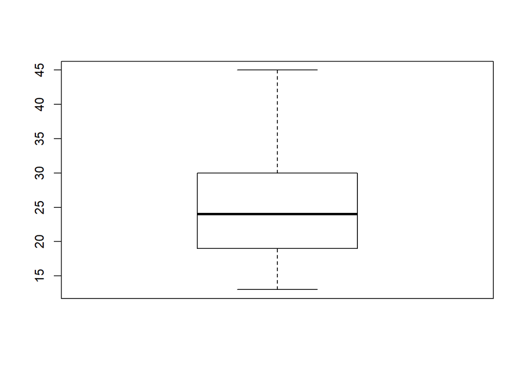

```r
#citympg
boxplot(data$CityMPG) #Outlier Present
```

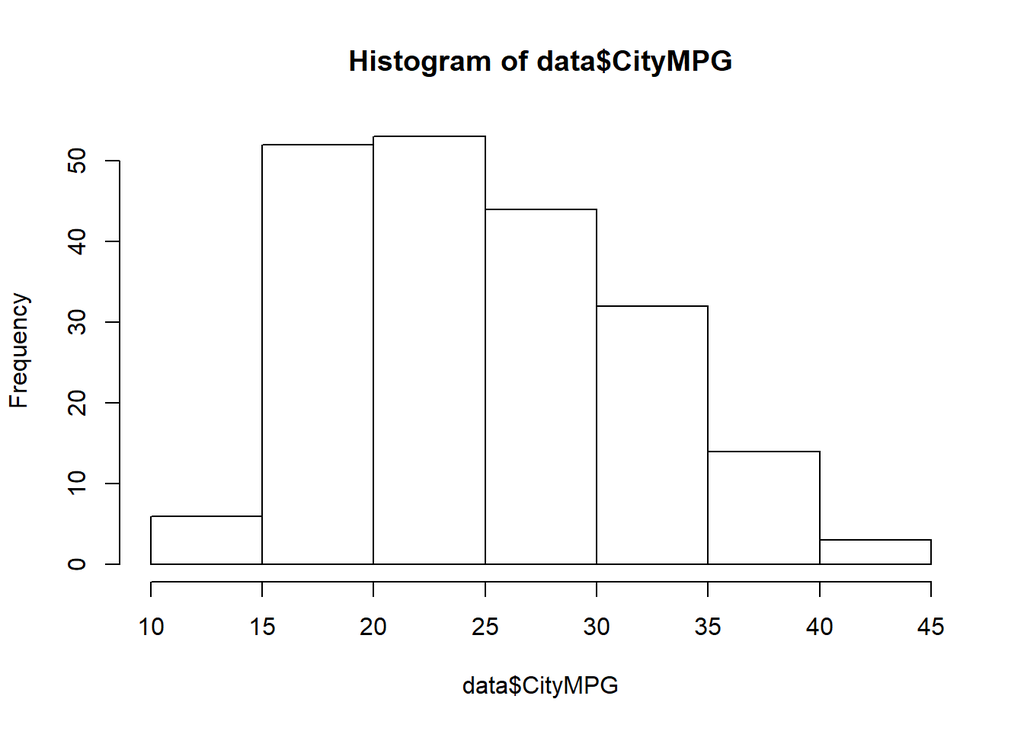

```r
hist(data$CityMPG) #Right Skew
```

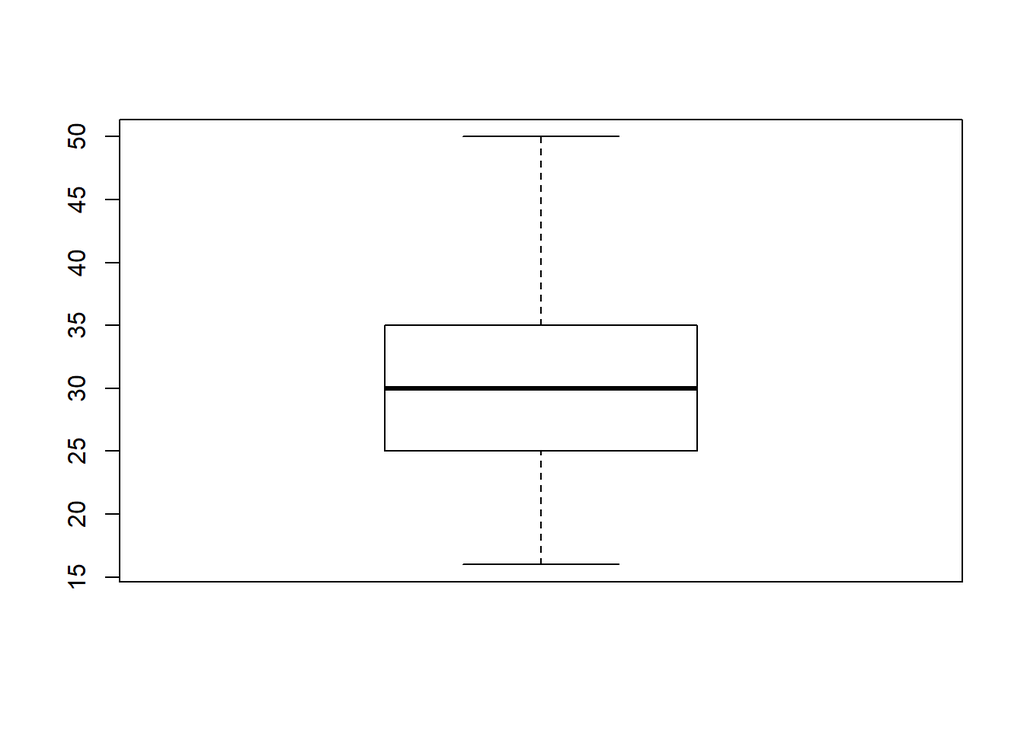

```r
#HighwasMPG
boxplot(data$HighwayMPG) #Outlier Present
```

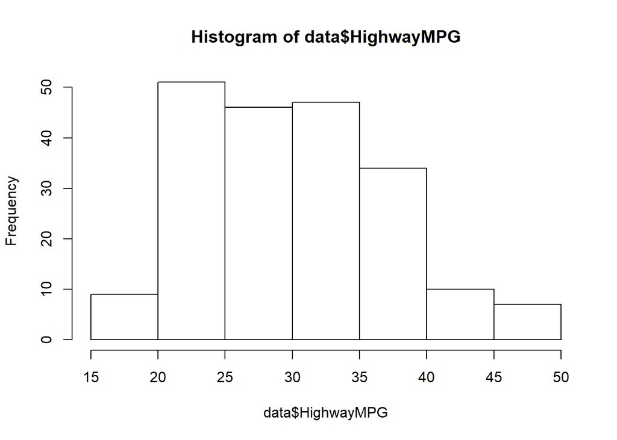

```r
hist(data$HighwayMPG) #Right Skew
```

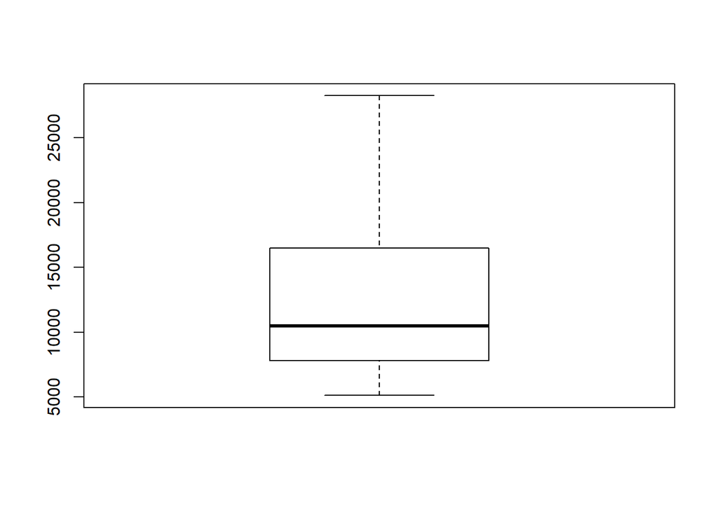

```r
#Price
boxplot(data$Price) #Outlier Present
```

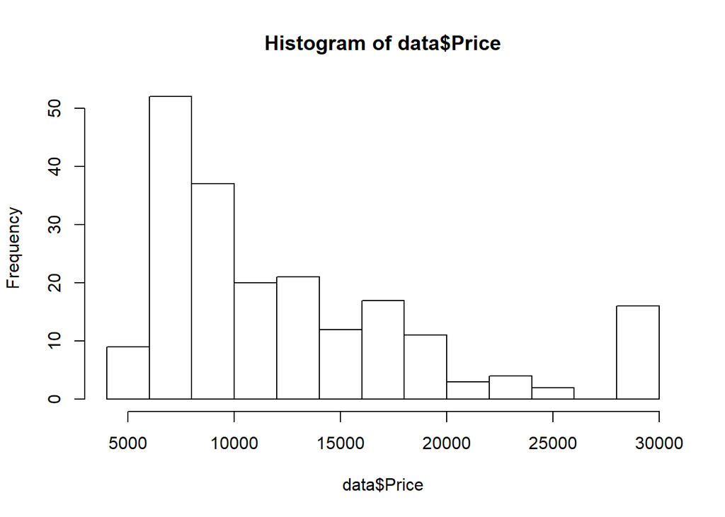

```r
hist(data$Price) #Right Skew
```

## Scaling - Standardization

Scaling helps and makes the numerical values as same units

```r
#Backup
dataset2 <- data #After Outlier and Missing Value Treatment
dataset4 <- dataset2


Scaled <- data #Taking Backup for Scaling
Scaled$RiskFactor <- NULL
Scaled$Make <- NULL
Scaled$FuelType <- NULL
Scaled$Asprtn <- NULL
Scaled$BodyStyle <- NULL
Scaled$EngineLoc <- NULL
Scaled$Drive <- NULL
Scaled$EngineType <- NULL
Scaled$Cylinder <- NULL
Scaled$FuelSystem <- NULL
Scaled$Door <- NULL

#Performing Scaling Operations to make units of all standard. So that model will give better accuracy

Scaled <- scale(Scaled)
Scaled <- as.data.frame(Scaled)
View(Scaled)
```

# Rejoining all the categorical variable for Further Processing

```r
str(data)
```

```
## 'data.frame':    204 obs. of  26 variables:
##  $ RiskFactor      : int  -2 -2 -1 -1 -1 -1 -1 -1 -1 -1 ...
##  $ Loss            : num  103 103 110 93 93 93 115 137 74 65 ...
##  $ Make            : Factor w/ 22 levels "alfa","audi",..: 22 22 5 10 10 10 10 12 15 20 ...
##  $ FuelType        : Factor w/ 2 levels "diesel","gas": 2 2 2 1 1 1 2 2 2 2 ...
##  $ Asprtn          : Factor w/ 2 levels "std","turbo": 1 2 1 2 2 2 1 1 1 1 ...
##  $ Door            : num  4 4 4 4 4 4 4 4 4 4 ...
##  $ BodyStyle       : Factor w/ 5 levels "convertible",..: 4 4 5 4 5 4 4 4 5 4 ...
##  $ Drive           : Factor w/ 3 levels "4wd","fwd","rwd": 3 3 2 3 3 3 3 2 2 2 ...
##  $ EngineLoc       : Factor w/ 2 levels "front","rear": 1 1 1 1 1 1 1 1 1 1 ...
##  $ WheelBase       : num  104 104 103 110 110 ...
##  $ Length          : num  189 189 175 191 191 ...
##  $ Width           : num  67.2 67.2 64.6 70.3 70.3 70.6 70.6 65.4 64.6 66.5 ...
##  $ Height          : num  56.2 56.2 59.8 56.5 58.7 56.3 56.5 51.6 59.8 54.9 ...
##  $ CurbWeight      : int  2935 3045 2535 3515 3750 3770 3740 2403 2535 2326 ...
##  $ EngineType      : Factor w/ 7 levels "dohc","dohcv",..: 4 4 4 4 4 4 6 4 4 4 ...
##  $ Cylinder        : Factor w/ 7 levels "eight","five",..: 3 3 3 2 2 2 1 3 3 3 ...
##  $ EngineSize      : num  141 130 122 183 183 183 209 110 122 122 ...
##  $ FuelSystem      : Factor w/ 8 levels "1bbl","2bbl",..: 6 6 2 4 4 4 6 7 2 6 ...
##  $ Bore            : num  3.78 3.62 3.34 3.58 3.58 3.58 3.46 3.17 3.35 3.31 ...
##  $ Stroke          : num  3.15 3.15 3.46 3.64 3.64 3.64 3.1 3.46 3.46 3.54 ...
##  $ CompressionRatio: num  9.5 7.5 8.5 10.1 10.1 10.1 8.3 7.5 8.5 8.7 ...
##  $ HorsePower      : num  114 162 88 123 123 123 155 116 88 92 ...
##  $ PeakRPM         : num  5400 5100 5000 4350 4350 4350 4750 5500 5000 4200 ...
##  $ CityMPG         : num  24 17 24 22 22 22 16 23 24 29 ...
##  $ HighwayMPG      : num  28 22 30 25 25 25 18 30 30 34 ...
##  $ Price           : num  15985 18420 8921 25552 28248 ...
```

```r
Scaled["Make"] <- data$Make
Scaled["FuelType"] <- data$FuelType
Scaled["Aspiration"] <- data$Asprtn
Scaled["BodyStyle"] <- data$BodyStyle
Scaled["Drive"] <- data$Drive
Scaled["EngineLocation"] <- data$EngineLoc
Scaled["EngineType"] <- data$EngineType
Scaled["Cylinder"] <- data$Cylinder
Scaled["FuelSystem"] <- data$FuelSystem
Scaled["Door"] <- data$Door
Scaled["RiskFactor"] <- data$RiskFactor

#Backup Dataset
Scaled_dataset3 <- Scaled
str(Scaled)
```

```
## 'data.frame':    204 obs. of  26 variables:
##  $ Loss            : num  -0.571 -0.571 -0.335 -0.907 -0.907 ...
##  $ WheelBase       : num  0.98 0.98 0.807 1.966 1.966 ...
##  $ Length          : num  1.2147 1.2147 0.0518 1.3867 1.3867 ...
##  $ Width           : num  0.66 0.66 -0.618 2.183 2.183 ...
##  $ Height          : num  1.02 1.02 2.49 1.14 2.04 ...
##  $ CurbWeight      : num  0.7311 0.9421 -0.0361 1.8436 2.2944 ...
##  $ EngineSize      : num  0.4788 0.1579 -0.0755 1.704 1.704 ...
##  $ Bore            : num  1.6793 1.0859 0.0476 0.9376 0.9376 ...
##  $ Stroke          : num  -0.415 -0.415 0.715 1.372 1.372 ...
##  $ CompressionRatio: num  0.736 -2.144 -0.704 1.6 1.6 ...
##  $ HorsePower      : num  0.328 1.628 -0.377 0.572 0.572 ...
##  $ PeakRPM         : num  0.6089 -0.0392 -0.2552 -1.6592 -1.6592 ...
##  $ CityMPG         : num  -0.186 -1.27 -0.186 -0.496 -0.496 ...
##  $ HighwayMPG      : num  -0.402 -1.285 -0.107 -0.843 -0.843 ...
##  $ Price           : num  0.518 0.9 -0.589 2.018 2.44 ...
##  $ Make            : Factor w/ 22 levels "alfa","audi",..: 22 22 5 10 10 10 10 12 15 20 ...
##  $ FuelType        : Factor w/ 2 levels "diesel","gas": 2 2 2 1 1 1 2 2 2 2 ...
##  $ Aspiration      : Factor w/ 2 levels "std","turbo": 1 2 1 2 2 2 1 1 1 1 ...
##  $ BodyStyle       : Factor w/ 5 levels "convertible",..: 4 4 5 4 5 4 4 4 5 4 ...
##  $ Drive           : Factor w/ 3 levels "4wd","fwd","rwd": 3 3 2 3 3 3 3 2 2 2 ...
##  $ EngineLocation  : Factor w/ 2 levels "front","rear": 1 1 1 1 1 1 1 1 1 1 ...
##  $ EngineType      : Factor w/ 7 levels "dohc","dohcv",..: 4 4 4 4 4 4 6 4 4 4 ...
##  $ Cylinder        : Factor w/ 7 levels "eight","five",..: 3 3 3 2 2 2 1 3 3 3 ...
##  $ FuelSystem      : Factor w/ 8 levels "1bbl","2bbl",..: 6 6 2 4 4 4 6 7 2 6 ...
##  $ Door            : num  4 4 4 4 4 4 4 4 4 4 ...
##  $ RiskFactor      : int  -2 -2 -1 -1 -1 -1 -1 -1 -1 -1 ...
```

## Feature Creation - Dummy Variable Creation

This helps in building more accuracy for our predictions

```r
#install.packages("mlr") #Packages for Dummy Variable Creation
library(mlr) #Library for Dummy Variable Creation
Scaled_backup <- Scaled_dataset3
Scaled <- Scaled_dataset3



#Fuel Type
#install.packages("dummies")
library(dummies)
#Fuel Type - 2 Factors
str(Scaled$FuelType)
```

```
##  Factor w/ 2 levels "diesel","gas": 2 2 2 1 1 1 2 2 2 2 ...
```

```r
FuelType <- cbind(Scaled$FuelType,dummy(Scaled$FuelType,sep = "_"))
FuelType<- as.data.frame(FuelType)
Scaled$FuelType <- NULL
Scaled["FuelType_Diesel"] <- FuelType[2]#Diesel Type 0,1
Scaled$FuelType_Diesel <- factor(Scaled$FuelType_Diesel)

#Aspiration
str(Scaled$Aspiration) # 2 Levels
```

```
##  Factor w/ 2 levels "std","turbo": 1 2 1 2 2 2 1 1 1 1 ...
```

```r
Turbo <- cbind(Scaled$Aspiration, dummy(Scaled$Aspiration,sep = "_"))
Turbo <- as.data.frame(Turbo)
Scaled["Aspiration_Turbo"] <- Turbo[3] #Turbo Type 0,1
Scaled$Aspiration <-NULL
Scaled$Aspiration_Turbo <- factor(Scaled$Aspiration_Turbo)
str(Scaled$Aspiration_Turbo)
```

```
##  Factor w/ 2 levels "0","1": 1 2 1 2 2 2 1 1 1 1 ...
```

```r
#Engine Location
str(Scaled$EngineLocation) #2 Levels
```

```
##  Factor w/ 2 levels "front","rear": 1 1 1 1 1 1 1 1 1 1 ...
```

```r
EngineLoc <- cbind(Scaled$EngineLocation, dummy(Scaled$EngineLocation,sep = "_"))
EngineLoc <- as.data.frame(EngineLoc)
Scaled["EngineLocation_Front"] <- EngineLoc[2]
Scaled$EngineLocation <- NULL
Scaled$EngineLocation_Front <- factor(Scaled$EngineLocation_Front)
str(Scaled$EngineLocation_Front)
```

```
##  Factor w/ 2 levels "0","1": 2 2 2 2 2 2 2 2 2 2 ...
```

```r
#Door
Scaled$Door <- factor(Scaled$Door)
str(Scaled$Door) #2 Factors
```

```
##  Factor w/ 2 levels "2","4": 2 2 2 2 2 2 2 2 2 2 ...
```

```r
Door <- cbind.data.frame(Scaled$Door,dummy(Scaled$Door,sep="_"))
Scaled["Door_2"] <- Door[2]
Scaled$Door <- NULL
Scaled$Door_2 <- factor(Scaled$Door_2)
str(Scaled$Door_2)
```

```
##  Factor w/ 2 levels "0","1": 1 1 1 1 1 1 1 1 1 1 ...
```

```r
#Drive
str(Scaled$Drive) #3 Levels
```

```
##  Factor w/ 3 levels "4wd","fwd","rwd": 3 3 2 3 3 3 3 2 2 2 ...
```

```r
Drive <- cbind.data.frame(Scaled$Drive,dummy(Scaled$Drive,sep = "_"))
Scaled["Drive_fwd"] <- Drive[3]
Scaled["Drive_rwd"] <- Drive[4]
Scaled$Drive <- NULL
Scaled$Drive_fwd <- factor(Scaled$Drive_fwd)
Scaled$Drive_rwd <- factor(Scaled$Drive_rwd)

#Risk Factor
str(Scaled)
```

```
## 'data.frame':    204 obs. of  27 variables:
##  $ Loss                : num  -0.571 -0.571 -0.335 -0.907 -0.907 ...
##  $ WheelBase           : num  0.98 0.98 0.807 1.966 1.966 ...
##  $ Length              : num  1.2147 1.2147 0.0518 1.3867 1.3867 ...
##  $ Width               : num  0.66 0.66 -0.618 2.183 2.183 ...
##  $ Height              : num  1.02 1.02 2.49 1.14 2.04 ...
##  $ CurbWeight          : num  0.7311 0.9421 -0.0361 1.8436 2.2944 ...
##  $ EngineSize          : num  0.4788 0.1579 -0.0755 1.704 1.704 ...
##  $ Bore                : num  1.6793 1.0859 0.0476 0.9376 0.9376 ...
##  $ Stroke              : num  -0.415 -0.415 0.715 1.372 1.372 ...
##  $ CompressionRatio    : num  0.736 -2.144 -0.704 1.6 1.6 ...
##  $ HorsePower          : num  0.328 1.628 -0.377 0.572 0.572 ...
##  $ PeakRPM             : num  0.6089 -0.0392 -0.2552 -1.6592 -1.6592 ...
##  $ CityMPG             : num  -0.186 -1.27 -0.186 -0.496 -0.496 ...
##  $ HighwayMPG          : num  -0.402 -1.285 -0.107 -0.843 -0.843 ...
##  $ Price               : num  0.518 0.9 -0.589 2.018 2.44 ...
##  $ Make                : Factor w/ 22 levels "alfa","audi",..: 22 22 5 10 10 10 10 12 15 20 ...
##  $ BodyStyle           : Factor w/ 5 levels "convertible",..: 4 4 5 4 5 4 4 4 5 4 ...
##  $ EngineType          : Factor w/ 7 levels "dohc","dohcv",..: 4 4 4 4 4 4 6 4 4 4 ...
##  $ Cylinder            : Factor w/ 7 levels "eight","five",..: 3 3 3 2 2 2 1 3 3 3 ...
##  $ FuelSystem          : Factor w/ 8 levels "1bbl","2bbl",..: 6 6 2 4 4 4 6 7 2 6 ...
##  $ RiskFactor          : int  -2 -2 -1 -1 -1 -1 -1 -1 -1 -1 ...
##  $ FuelType_Diesel     : Factor w/ 2 levels "0","1": 1 1 1 2 2 2 1 1 1 1 ...
##  $ Aspiration_Turbo    : Factor w/ 2 levels "0","1": 1 2 1 2 2 2 1 1 1 1 ...
##  $ EngineLocation_Front: Factor w/ 2 levels "0","1": 2 2 2 2 2 2 2 2 2 2 ...
##  $ Door_2              : Factor w/ 2 levels "0","1": 1 1 1 1 1 1 1 1 1 1 ...
##  $ Drive_fwd           : Factor w/ 2 levels "0","1": 1 1 2 1 1 1 1 2 2 2 ...
##  $ Drive_rwd           : Factor w/ 2 levels "0","1": 2 2 1 2 2 2 2 1 1 1 ...
```

```r
Scaled$RiskFactor <- NULL
Scaled["RiskFactor"] <- data$RiskFactor
Scaled$RiskFactor <- factor(Scaled$RiskFactor)
str(Scaled)
```

```
## 'data.frame':    204 obs. of  27 variables:
##  $ Loss                : num  -0.571 -0.571 -0.335 -0.907 -0.907 ...
##  $ WheelBase           : num  0.98 0.98 0.807 1.966 1.966 ...
##  $ Length              : num  1.2147 1.2147 0.0518 1.3867 1.3867 ...
##  $ Width               : num  0.66 0.66 -0.618 2.183 2.183 ...
##  $ Height              : num  1.02 1.02 2.49 1.14 2.04 ...
##  $ CurbWeight          : num  0.7311 0.9421 -0.0361 1.8436 2.2944 ...
##  $ EngineSize          : num  0.4788 0.1579 -0.0755 1.704 1.704 ...
##  $ Bore                : num  1.6793 1.0859 0.0476 0.9376 0.9376 ...
##  $ Stroke              : num  -0.415 -0.415 0.715 1.372 1.372 ...
##  $ CompressionRatio    : num  0.736 -2.144 -0.704 1.6 1.6 ...
##  $ HorsePower          : num  0.328 1.628 -0.377 0.572 0.572 ...
##  $ PeakRPM             : num  0.6089 -0.0392 -0.2552 -1.6592 -1.6592 ...
##  $ CityMPG             : num  -0.186 -1.27 -0.186 -0.496 -0.496 ...
##  $ HighwayMPG          : num  -0.402 -1.285 -0.107 -0.843 -0.843 ...
##  $ Price               : num  0.518 0.9 -0.589 2.018 2.44 ...
##  $ Make                : Factor w/ 22 levels "alfa","audi",..: 22 22 5 10 10 10 10 12 15 20 ...
##  $ BodyStyle           : Factor w/ 5 levels "convertible",..: 4 4 5 4 5 4 4 4 5 4 ...
##  $ EngineType          : Factor w/ 7 levels "dohc","dohcv",..: 4 4 4 4 4 4 6 4 4 4 ...
##  $ Cylinder            : Factor w/ 7 levels "eight","five",..: 3 3 3 2 2 2 1 3 3 3 ...
##  $ FuelSystem          : Factor w/ 8 levels "1bbl","2bbl",..: 6 6 2 4 4 4 6 7 2 6 ...
##  $ FuelType_Diesel     : Factor w/ 2 levels "0","1": 1 1 1 2 2 2 1 1 1 1 ...
##  $ Aspiration_Turbo    : Factor w/ 2 levels "0","1": 1 2 1 2 2 2 1 1 1 1 ...
##  $ EngineLocation_Front: Factor w/ 2 levels "0","1": 2 2 2 2 2 2 2 2 2 2 ...
##  $ Door_2              : Factor w/ 2 levels "0","1": 1 1 1 1 1 1 1 1 1 1 ...
##  $ Drive_fwd           : Factor w/ 2 levels "0","1": 1 1 2 1 1 1 1 2 2 2 ...
##  $ Drive_rwd           : Factor w/ 2 levels "0","1": 2 2 1 2 2 2 2 1 1 1 ...
##  $ RiskFactor          : Factor w/ 6 levels "-2","-1","0",..: 1 1 2 2 2 2 2 2 2 2 ...
```

## Correlation

To Check whether there is any multi Collinearity Exists

Correlation Values: -0.7 to -1 - Strong Negative Correlation 0 - No Correlation 0.7 to 1 - Strong Positive Correlation

```r
#In Scaled Data

Corelation_Scaled <- Scaled
#Removing Categorical Variable and Leaving only Numerical Variable to check Co-Relation
Corelation_Scaled$Make <- NULL
Corelation_Scaled$BodyStyle <- NULL
Corelation_Scaled$EngineType <- NULL
Corelation_Scaled$Cylinder <- NULL
Corelation_Scaled$FuelSystem <- NULL
Corelation_Scaled$FuelType_Diesel <- NULL
Corelation_Scaled$Aspiration_Turbo <- NULL
Corelation_Scaled$Drive_fwd <- NULL
Corelation_Scaled$Drive_rwd <- NULL
Corelation_Scaled$EngineLocation_Front <- NULL
Corelation_Scaled$Door_2 <- NULL
Corelation_Scaled$RiskFactor <- NULL

cor(Corelation_Scaled)
```

```
##                           Loss   WheelBase        Length       Width
## Loss              1.0000000000 -0.06816388 -0.0005675904  0.06777276
## WheelBase        -0.0681638846  1.00000000  0.8744445225  0.80213973
## Length           -0.0005675904  0.87444452  1.0000000000  0.84963073
## Width             0.0677727649  0.80213973  0.8496307273  1.00000000
## Height           -0.3630714183  0.59215070  0.4895241100  0.28091911
## CurbWeight        0.0661065356  0.77518708  0.8773135155  0.87615839
## EngineSize        0.0849828763  0.55601170  0.7001409968  0.74205922
## Bore             -0.0475562450  0.48840936  0.6029710146  0.56863092
## Stroke            0.0520969757  0.19487860  0.1546399442  0.21171378
## CompressionRatio -0.0676230798 -0.06249144 -0.1246726178 -0.10387514
## HorsePower        0.1829286415  0.39953561  0.5701795303  0.62101287
## PeakRPM           0.2356499882 -0.36357838 -0.2953969635 -0.22614159
## CityMPG          -0.1949987316 -0.47046164 -0.6682845372 -0.65316790
## HighwayMPG       -0.1515180635 -0.54143967 -0.7010468448 -0.68748841
## Price             0.1290976724  0.61315847  0.7217510132  0.76497401
##                       Height  CurbWeight  EngineSize        Bore
## Loss             -0.36307142  0.06610654  0.08498288 -0.04755625
## WheelBase         0.59215070  0.77518708  0.55601170  0.48840936
## Length            0.48952411  0.87731352  0.70014100  0.60297101
## Width             0.28091911  0.87615839  0.74205922  0.56863092
## Height            1.00000000  0.29323578  0.09923195  0.16676465
## CurbWeight        0.29323578  1.00000000  0.86667919  0.64841713
## EngineSize        0.09923195  0.86667919  1.00000000  0.63319149
## Bore              0.16676465  0.64841713  0.63319149  1.00000000
## Stroke           -0.02371299  0.17800110  0.22188069 -0.08377794
## CompressionRatio  0.08158403 -0.16582743 -0.16009563 -0.14232082
## HorsePower       -0.05541868  0.75227039  0.80450687  0.55195162
## PeakRPM          -0.32912257 -0.27070873 -0.23970149 -0.26845008
## CityMPG          -0.04383247 -0.76074451 -0.68894792 -0.58573687
## HighwayMPG       -0.10340711 -0.80066042 -0.69807947 -0.58760896
## Price             0.16565662  0.85514108  0.83974296  0.55814835
##                       Stroke CompressionRatio  HorsePower     PeakRPM
## Loss              0.05209698      -0.06762308  0.18292864  0.23564999
## WheelBase         0.19487860      -0.06249144  0.39953561 -0.36357838
## Length            0.15463994      -0.12467262  0.57017953 -0.29539696
## Width             0.21171378      -0.10387514  0.62101287 -0.22614159
## Height           -0.02371299       0.08158403 -0.05541868 -0.32912257
## CurbWeight        0.17800110      -0.16582743  0.75227039 -0.27070873
## EngineSize        0.22188069      -0.16009563  0.80450687 -0.23970149
```

[output cut: 9 more lines]

```
## Loss             -0.19499873 -0.15151806  0.12909767
## WheelBase        -0.47046164 -0.54143967  0.61315847
## Length           -0.66828454 -0.70104684  0.72175101
## Width            -0.65316790 -0.68748841  0.76497401
## Height           -0.04383247 -0.10340711  0.16565662
## CurbWeight       -0.76074451 -0.80066042  0.85514108
## EngineSize       -0.68894792 -0.69807947  0.83974296
## Bore             -0.58573687 -0.58760896  0.55814835
## Stroke           -0.04948479 -0.04988175  0.07733276
## CompressionRatio  0.48530952  0.46019626 -0.10694163
## HorsePower       -0.80800173 -0.79761030  0.78038217
## PeakRPM          -0.11761030 -0.05035279 -0.10562493
## CityMPG           1.00000000  0.97037072 -0.70624303
## HighwayMPG        0.97037072  1.00000000 -0.72558118
## Price            -0.70624303 -0.72558118  1.00000000
```

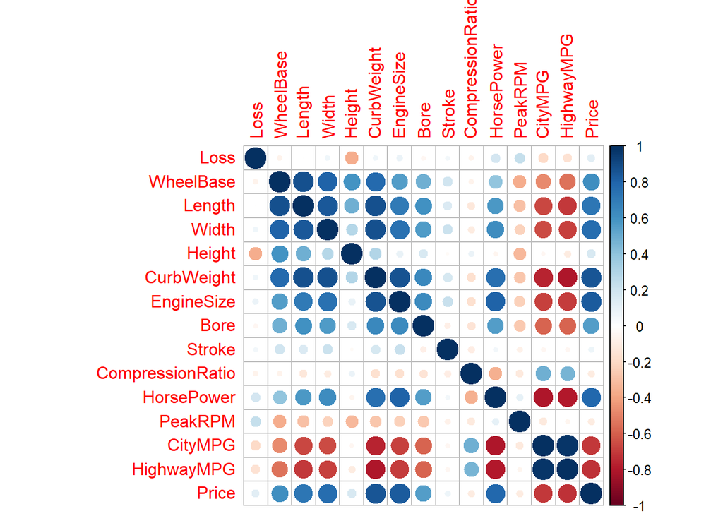

```r
#install.packages("corrplot")
library(corrplot)
corrplot(cor(Corelation_Scaled)) #Found MultiCollinearity Exist - Alert and Solve it
```

```r
#Multi Collinearity Exists - Alert
```

## Log Transformation# - For Reference

To make data point and variable as linear distribution and lets check for correlation again

```r
dataset5<- dataset4 #Backing Up
#To check whether multicollinearity is solved.
View(dataset4)
dataset4$RiskFactor <- NULL
dataset4$Make <- NULL
dataset4$FuelType <- NULL
dataset4$Asprtn <- NULL
dataset4$BodyStyle <- NULL
dataset4$EngineLoc <- NULL
dataset4$Drive <- NULL
dataset4$EngineType <- NULL
dataset4$Cylinder <- NULL
dataset4$FuelSystem <- NULL
dataset4$Door <- NULL


x <- log10(dataset4) #Applying Log10 because most variables are right skewed
cor(x)
```

```
##                          Loss   WheelBase       Length      Width
## Loss              1.000000000 -0.08228540  0.002168462  0.0683363
## WheelBase        -0.082285396  1.00000000  0.865901656  0.7998052
## Length            0.002168462  0.86590166  1.000000000  0.8445209
## Width             0.068336299  0.79980515  0.844520872  1.0000000
## Height           -0.379146101  0.59360536  0.481078610  0.2762777
## CurbWeight        0.068419487  0.76321748  0.886237317  0.8714227
## EngineSize        0.076627250  0.57372668  0.726900634  0.7497970
## Bore             -0.048861504  0.48715041  0.610128102  0.5677512
## Stroke            0.077363437  0.19298098  0.145016596  0.2052666
## CompressionRatio -0.073285451 -0.07329924 -0.132867098 -0.1174319
## HorsePower        0.144274992  0.33706533  0.416381798  0.4493990
## PeakRPM           0.257109399 -0.36985499 -0.295772765 -0.2297470
## CityMPG          -0.208757285 -0.47376963 -0.671766430 -0.6785315
## HighwayMPG       -0.154554245 -0.55738438 -0.710015801 -0.7167301
## Price             0.154702469  0.63516731  0.768749906  0.7876537
##                       Height  CurbWeight  EngineSize        Bore
## Loss             -0.37914610  0.06841949  0.07662725 -0.04886150
## WheelBase         0.59360536  0.76321748  0.57372668  0.48715041
## Length            0.48107861  0.88623732  0.72690063  0.61012810
## Width             0.27627772  0.87142270  0.74979701  0.56775117
## Height            1.00000000  0.29158921  0.13536243  0.16333744
## CurbWeight        0.29158921  1.00000000  0.86620163  0.66686782
## EngineSize        0.13536243  0.86620163  1.00000000  0.65228465
## Bore              0.16333744  0.66686782  0.65228465  1.00000000
## Stroke           -0.01772762  0.16069622  0.22125165 -0.09697688
## CompressionRatio  0.08508042 -0.19651852 -0.18836955 -0.15535137
## HorsePower       -0.01290682  0.56122265  0.55013489  0.38860428
## PeakRPM          -0.33223650 -0.26555777 -0.27086860 -0.27529796
## CityMPG          -0.01341826 -0.80455045 -0.71189805 -0.57724705
## HighwayMPG       -0.08827530 -0.83724874 -0.71743495 -0.57731971
## Price             0.18148118  0.88158595  0.81478864  0.59169707
##                       Stroke CompressionRatio  HorsePower     PeakRPM
## Loss              0.07736344      -0.07328545  0.14427499  0.25710940
## WheelBase         0.19298098      -0.07329924  0.33706533 -0.36985499
## Length            0.14501660      -0.13286710  0.41638180 -0.29577277
## Width             0.20526656      -0.11743189  0.44939901 -0.22974697
## Height           -0.01772762       0.08508042 -0.01290682 -0.33223650
## CurbWeight        0.16069622      -0.19651852  0.56122265 -0.26555777
## EngineSize        0.22125165      -0.18836955  0.55013489 -0.27086860
```

[output cut: 9 more lines]

```
## Loss             -0.20875729 -0.15455425  0.15470247
## WheelBase        -0.47376963 -0.55738438  0.63516731
## Length           -0.67176643 -0.71001580  0.76874991
## Width            -0.67853155 -0.71673006  0.78765373
## Height           -0.01341826 -0.08827530  0.18148118
## CurbWeight       -0.80455045 -0.83724874  0.88158595
## EngineSize       -0.71189805 -0.71743495  0.81478864
## Bore             -0.57724705 -0.57731971  0.59169707
## Stroke           -0.03385265 -0.03885570  0.09162495
## CompressionRatio  0.47808101  0.45760597 -0.14657503
## HorsePower       -0.62257746 -0.62724882  0.60402052
## PeakRPM          -0.12564345 -0.03299781 -0.10853242
## CityMPG           1.00000000  0.96422871 -0.79135415
## HighwayMPG        0.96422871  1.00000000 -0.79534763
## Price            -0.79135415 -0.79534763  1.00000000
```

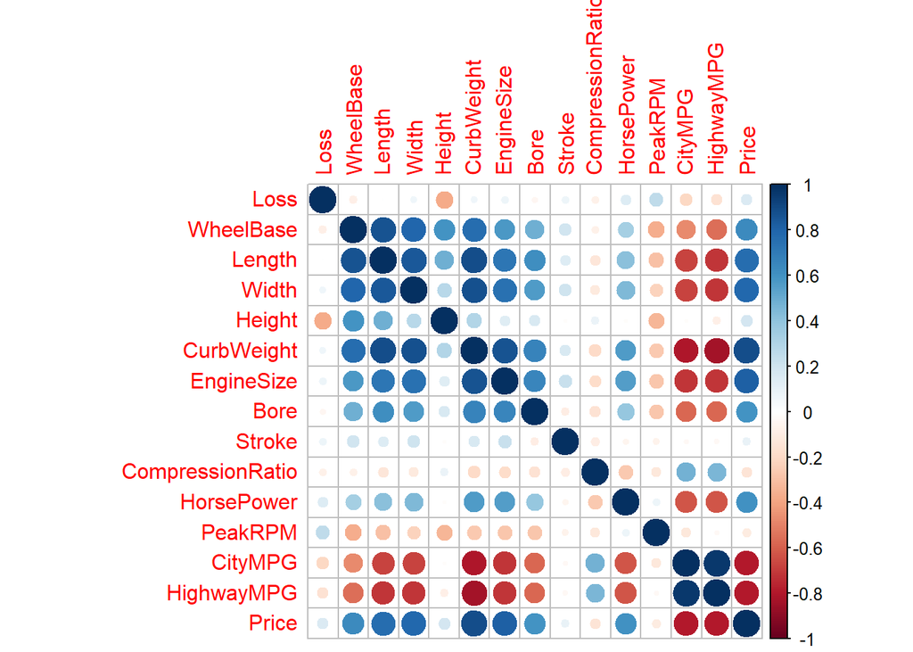

```r
corrplot((cor(x))) #MultiCollinearity Still Exist
```

## MultiCollinearity Issue - Solving it

Multi Collinearity can be solved by many methods like Priciple Component Analysis Factor Analysis Ridge Regression Lasso Regression

But as the Categorical variable are grouped with continuous variable in same data set.

I have applying VIF - Variable Inflation Factor to eliminate Correlated Variable.

```r
#Removing Multi Collinearity by using VIF and Corrplot

#install.packages("HH")
library(HH)
vif(Corelation_Scaled)
```

```
##             Loss        WheelBase           Length            Width
##         1.307481         7.311682         9.335586         5.969961
##           Height       CurbWeight       EngineSize             Bore
##         2.454613        15.697791         7.896805         2.280881
##           Stroke CompressionRatio       HorsePower          PeakRPM
##         1.408046         1.812812         6.112947         2.076089
##          CityMPG       HighwayMPG            Price
##        24.636254        23.063039         5.438324
```

```r
sample_Scaled <- Corelation_Scaled
#Check for VIF Value and Remove the max value. Repeat untill dataset with no corelationsample_Scaled <- Corelation_Scaled
vif(sample_Scaled)
```

```
##             Loss        WheelBase           Length            Width
##         1.307481         7.311682         9.335586         5.969961
##           Height       CurbWeight       EngineSize             Bore
##         2.454613        15.697791         7.896805         2.280881
##           Stroke CompressionRatio       HorsePower          PeakRPM
##         1.408046         1.812812         6.112947         2.076089
##          CityMPG       HighwayMPG            Price
##        24.636254        23.063039         5.438324
```

```r
sample_Scaled$CityMPG <- NULL
vif(sample_Scaled)
```

```
##             Loss        WheelBase           Length            Width
##         1.282866         6.731635         8.567245         5.956851
##           Height       CurbWeight       EngineSize             Bore
##         2.454317        15.643018         7.871392         2.206765
##           Stroke CompressionRatio       HorsePower          PeakRPM
##         1.407008         1.720871         6.096616         1.954645
##       HighwayMPG            Price
##         6.015458         5.435253
```

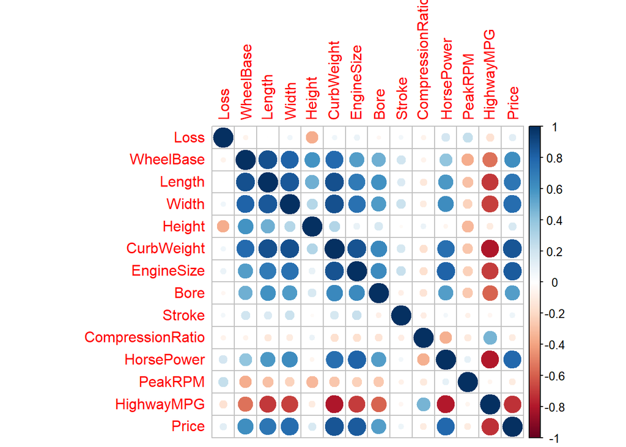

```r
corrplot(cor(sample_Scaled))
```

```r
sample_Scaled$CurbWeight <- NULL
vif(sample_Scaled)
```

```
##             Loss        WheelBase           Length            Width
##         1.282426         6.568200         8.088809         5.596167
##           Height       EngineSize             Bore           Stroke
##         2.452331         7.102303         2.206245         1.399130
## CompressionRatio       HorsePower          PeakRPM       HighwayMPG
##         1.666267         5.962718         1.812075         5.110375
##            Price
##         5.237885
```

```r
sample_Scaled$Length <- NULL
vif(sample_Scaled)
```

```
##             Loss        WheelBase            Width           Height
##         1.272288         5.337901         5.209261         2.264203
##       EngineSize             Bore           Stroke CompressionRatio
##         7.013468         2.171432         1.398678         1.652864
##       HorsePower          PeakRPM       HighwayMPG            Price
##         5.961910         1.806967         4.665156         5.237883
```

```r
sample_Scaled$EngineSize<- NULL
vif(sample_Scaled)
```

```
##             Loss        WheelBase            Width           Height
##         1.271747         5.215779         5.083869         2.263534
##             Bore           Stroke CompressionRatio       HorsePower
##         2.051962         1.198847         1.627315         4.519514
##          PeakRPM       HighwayMPG            Price
##         1.493915         4.663756         4.369028
```

```r
sample_Scaled$WheelBase <- NULL
vif(sample_Scaled)
```

```
##             Loss            Width           Height             Bore
##         1.260939         3.438735         1.478166         2.045830
##           Stroke CompressionRatio       HorsePower          PeakRPM
##         1.171438         1.627013         4.471673         1.448518
##       HighwayMPG            Price
##         4.602461         4.340428
```

```r
sample_Scaled$HighwayMPG <- NULL
vif(sample_Scaled)
```

```
##             Loss            Width           Height             Bore
##         1.251830         3.104149         1.457895         1.939514
##           Stroke CompressionRatio       HorsePower          PeakRPM
##         1.162333         1.268199         4.051957         1.389714
##            Price
##         4.211124
```

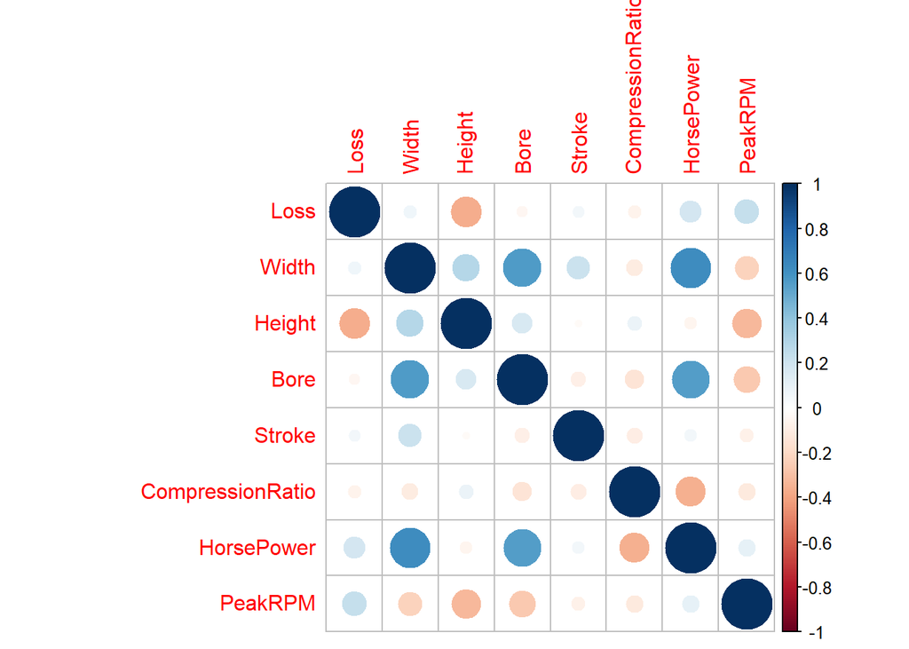

```r
sample_Scaled$Price <- NULL
corrplot(cor(sample_Scaled)) #Multi Collinearity Removed
```

```r
cor(sample_Scaled) #All Corelation value is under 0.7
```

```
##                         Loss       Width      Height        Bore
## Loss              1.00000000  0.06777276 -0.36307142 -0.04755625
## Width             0.06777276  1.00000000  0.28091911  0.56863092
## Height           -0.36307142  0.28091911  1.00000000  0.16676465
## Bore             -0.04755625  0.56863092  0.16676465  1.00000000
## Stroke            0.05209698  0.21171378 -0.02371299 -0.08377794
## CompressionRatio -0.06762308 -0.10387514  0.08158403 -0.14232082
## HorsePower        0.18292864  0.62101287 -0.05541868  0.55195162
## PeakRPM           0.23564999 -0.22614159 -0.32912257 -0.26845008
##                       Stroke CompressionRatio  HorsePower     PeakRPM
## Loss              0.05209698      -0.06762308  0.18292864  0.23564999
## Width             0.21171378      -0.10387514  0.62101287 -0.22614159
## Height           -0.02371299       0.08158403 -0.05541868 -0.32912257
## Bore             -0.08377794      -0.14232082  0.55195162 -0.26845008
## Stroke            1.00000000      -0.09871683  0.05548829 -0.07092575
## CompressionRatio -0.09871683       1.00000000 -0.35514350 -0.11471777
## HorsePower        0.05548829      -0.35514350  1.00000000  0.10918153
## PeakRPM          -0.07092575      -0.11471777  0.10918153  1.00000000
```

Multi Collinearity is removed using VIF Functions

## Merging all categorical Variable

```r
str(Scaled[16:27])
```

```
## 'data.frame':    204 obs. of  12 variables:
##  $ Make                : Factor w/ 22 levels "alfa","audi",..: 22 22 5 10 10 10 10 12 15 20 ...
##  $ BodyStyle           : Factor w/ 5 levels "convertible",..: 4 4 5 4 5 4 4 4 5 4 ...
##  $ EngineType          : Factor w/ 7 levels "dohc","dohcv",..: 4 4 4 4 4 4 6 4 4 4 ...
##  $ Cylinder            : Factor w/ 7 levels "eight","five",..: 3 3 3 2 2 2 1 3 3 3 ...
##  $ FuelSystem          : Factor w/ 8 levels "1bbl","2bbl",..: 6 6 2 4 4 4 6 7 2 6 ...
##  $ FuelType_Diesel     : Factor w/ 2 levels "0","1": 1 1 1 2 2 2 1 1 1 1 ...
##  $ Aspiration_Turbo    : Factor w/ 2 levels "0","1": 1 2 1 2 2 2 1 1 1 1 ...
##  $ EngineLocation_Front: Factor w/ 2 levels "0","1": 2 2 2 2 2 2 2 2 2 2 ...
##  $ Door_2              : Factor w/ 2 levels "0","1": 1 1 1 1 1 1 1 1 1 1 ...
##  $ Drive_fwd           : Factor w/ 2 levels "0","1": 1 1 2 1 1 1 1 2 2 2 ...
##  $ Drive_rwd           : Factor w/ 2 levels "0","1": 2 2 1 2 2 2 2 1 1 1 ...
##  $ RiskFactor          : Factor w/ 6 levels "-2","-1","0",..: 1 1 2 2 2 2 2 2 2 2 ...
```

```r
sample_Scaled$Make <- Scaled$Make
sample_Scaled$BodyStyle <- Scaled$BodyStyle
sample_Scaled$EngineType <- Scaled$EngineType
sample_Scaled$Cylinder <- Scaled$Cylinder
sample_Scaled$FuelSystem <- Scaled$FuelSystem
sample_Scaled$FuelType_Diesel <- Scaled$FuelType_Diesel
sample_Scaled$Aspiration_Turbo <- Scaled$Aspiration_Turbo
sample_Scaled$EngineLocation_Front <- Scaled$EngineLocation_Front
sample_Scaled$Door_2 <- Scaled$Door_2
sample_Scaled$Drive_fwd <- Scaled$Drive_fwd
sample_Scaled$Drive_rwd <- Scaled$Drive_rwd
sample_Scaled$RiskFactor <- Scaled$RiskFactor
str(sample_Scaled)
```

```
## 'data.frame':    204 obs. of  20 variables:
##  $ Loss                : num  -0.571 -0.571 -0.335 -0.907 -0.907 ...
##  $ Width               : num  0.66 0.66 -0.618 2.183 2.183 ...
##  $ Height              : num  1.02 1.02 2.49 1.14 2.04 ...
##  $ Bore                : num  1.6793 1.0859 0.0476 0.9376 0.9376 ...
##  $ Stroke              : num  -0.415 -0.415 0.715 1.372 1.372 ...
##  $ CompressionRatio    : num  0.736 -2.144 -0.704 1.6 1.6 ...
##  $ HorsePower          : num  0.328 1.628 -0.377 0.572 0.572 ...
##  $ PeakRPM             : num  0.6089 -0.0392 -0.2552 -1.6592 -1.6592 ...
##  $ Make                : Factor w/ 22 levels "alfa","audi",..: 22 22 5 10 10 10 10 12 15 20 ...
##  $ BodyStyle           : Factor w/ 5 levels "convertible",..: 4 4 5 4 5 4 4 4 5 4 ...
##  $ EngineType          : Factor w/ 7 levels "dohc","dohcv",..: 4 4 4 4 4 4 6 4 4 4 ...
##  $ Cylinder            : Factor w/ 7 levels "eight","five",..: 3 3 3 2 2 2 1 3 3 3 ...
##  $ FuelSystem          : Factor w/ 8 levels "1bbl","2bbl",..: 6 6 2 4 4 4 6 7 2 6 ...
##  $ FuelType_Diesel     : Factor w/ 2 levels "0","1": 1 1 1 2 2 2 1 1 1 1 ...
##  $ Aspiration_Turbo    : Factor w/ 2 levels "0","1": 1 2 1 2 2 2 1 1 1 1 ...
##  $ EngineLocation_Front: Factor w/ 2 levels "0","1": 2 2 2 2 2 2 2 2 2 2 ...
##  $ Door_2              : Factor w/ 2 levels "0","1": 1 1 1 1 1 1 1 1 1 1 ...
##  $ Drive_fwd           : Factor w/ 2 levels "0","1": 1 1 2 1 1 1 1 2 2 2 ...
##  $ Drive_rwd           : Factor w/ 2 levels "0","1": 2 2 1 2 2 2 2 1 1 1 ...
##  $ RiskFactor          : Factor w/ 6 levels "-2","-1","0",..: 1 1 2 2 2 2 2 2 2 2 ...
```

```r
Final_data <- sample_Scaled #Backup
```

# Boruta# - #Finding Variable importance to improve accuracy

To find the significant variables present in the dataset and Important, Unimportant and Tendentive Variables will be separated automatically. By using it we can eliminate the variables.

```r
set.seed(123)
#install.packages("Boruta")
#install.packages("rFerns")
library(Boruta)
library(rFerns)

#Run Boruta on this data
Boruta(RiskFactor~.,data=sample_Scaled,doTrace=2)->Boruta.Scaled
```

[output not shown]

[output not shown]

[output not shown]

[output not shown]

[output not shown]

[output not shown]

[output not shown]

[output not shown]

[output not shown]

[output not shown]

[output not shown]

```
## After 11 iterations, +2 secs:
```

```
##  confirmed 16 attributes: BodyStyle, Bore, CompressionRatio, Cylinder, Door_2 and 11 more;
```

```
##  still have 3 attributes left.
```

[output not shown]

[output not shown]

[output not shown]

[output not shown]

[output not shown]

[output not shown]

[output not shown]

[output not shown]

[output not shown]

[output not shown]

[output not shown]

[output not shown]

[output not shown]

[output not shown]

[output not shown]

[output not shown]

[output not shown]

[output not shown]

[output not shown]

[output not shown]

[output not shown]

[output not shown]

[output not shown]

[output not shown]

[output not shown]

[output not shown]

[output not shown]

[output not shown]

[output not shown]

[output not shown]

[output not shown]

[output not shown]

[output not shown]

[output not shown]

[output not shown]

[output not shown]

[output not shown]

[output not shown]

[output not shown]

[output not shown]

[output not shown]

[output not shown]

[output not shown]

[output not shown]

[output not shown]

[output not shown]

[output not shown]

[output not shown]

[output not shown]

[output not shown]

[output not shown]

[output not shown]

[output not shown]

[output not shown]

[output not shown]

[output not shown]

[output not shown]

[output not shown]

[output not shown]

[output not shown]

[output not shown]

[output not shown]

[output not shown]

[output not shown]

[output not shown]

[output not shown]

[output not shown]

[output not shown]

[output not shown]

[output not shown]

[output not shown]

[output not shown]

[output not shown]

[output not shown]

[output not shown]

[output not shown]

[output not shown]

[output not shown]

[output not shown]

[output not shown]

[output not shown]

[output not shown]

[output not shown]

[output not shown]

[output not shown]

[output not shown]

[output not shown]

[output not shown]

```r
print(Boruta.Scaled)
```

```
## Boruta performed 99 iterations in 14.22655 secs.
##  16 attributes confirmed important: BodyStyle, Bore,
## CompressionRatio, Cylinder, Door_2 and 11 more;
##  No attributes deemed unimportant.
##  3 tentative attributes left: Aspiration_Turbo,
## EngineLocation_Front, FuelType_Diesel;
```

```r
#Boruta using rFerns' importance
Boruta(RiskFactor~.,data=sample_Scaled,getImp=getImpFerns)->Boruta.ferns.Scaled
print(Boruta.ferns.Scaled)
```

```
## Boruta performed 99 iterations in 2.825324 secs.
##  17 attributes confirmed important: Aspiration_Turbo, BodyStyle,
## Bore, CompressionRatio, Cylinder and 12 more;
##  1 attributes confirmed unimportant: EngineLocation_Front;
##  1 tentative attributes left: FuelType_Diesel;
```

```r
#By using Boruta - It is Confirmed that EngineLocation_Front is unimportant Variable
sample_Scaled$EngineLocation_Front <- NULL
```

All Exploratory data analysis methods have been completed successfully. All data Preprocessing steps have been completed successfully which may help in model accuracy.

## Buliding Models using various Machine Learning Algorithm using Cross Validation

Models used are listed below:

Lets compare the various models accuracy and improve its tuning parameters as well.

Predicting both Insample Prediction and Outsample Prediction. Insample Prediction: Predicting the train data itself which we used to build model Outsample Prediction: Predicting the test data for which we need to check accuracy

## Cross Validation

Sometimes prediction may work well in training set but accuracy will be very low in test set which cause overfitting issue. To resolve this issue, cross validation helps us.

We can split the data in to blocks and we can calculate accuracy for each and every blocks and by using it we can also predict the overall accuracy.

Split every block with 10% of data, and adding top 3 accuracy blocks as test set and remaining as training set.

## 1. Support Vector Machine

```r
#K-Fold Cross Validations
#install.packages("caret")
#install.packages("e1071")
library(caret)
library(e1071)
set.seed(123)
Ins_folds = createFolds(sample_Scaled$RiskFactor, k=10) #Creating Folds
Ins_folds$Fold01
```

```
##  [1]   6  24  55  57  65  67  75  84  96 130 131 139 142 147 167 176 193
## [18] 194 198
```

```r
SVM_CrossValidation = lapply(Ins_folds,function(x) {
  Ins_train_fold = sample_Scaled[-x,]
  Ins_test_fold = sample_Scaled[x,]
  Ins_classifier = svm(RiskFactor~., data=  Ins_train_fold)
  Ins_pred = predict(Ins_classifier,Ins_test_fold[-19])
  return(confusionMatrix(Ins_test_fold[,19],Ins_pred))
  })
print(SVM_CrossValidation) #Gets Summary for different 10 folds
```

```
## $Fold01
## Confusion Matrix and Statistics
##
##           Reference
## Prediction -2 -1 0 1 2 3
##         -2  0  0 0 0 0 0
##         -1  0  0 2 0 0 0
##         0   0  0 6 0 0 0
##         1   0  0 1 4 0 0
##         2   0  0 2 0 1 0
##         3   0  0 0 0 1 2
##
## Overall Statistics
##
##                Accuracy : 0.6842
##                  95% CI : (0.4345, 0.8742)
##     No Information Rate : 0.5789
##     P-Value [Acc > NIR] : 0.2455
##
##                   Kappa : 0.5665
##  Mcnemar's Test P-Value : NA
##
## Statistics by Class:
##
##                      Class: -2 Class: -1 Class: 0 Class: 1 Class: 2
## Sensitivity                 NA        NA   0.5455   1.0000  0.50000
## Specificity                  1    0.8947   1.0000   0.9333  0.88235
## Pos Pred Value              NA        NA   1.0000   0.8000  0.33333
## Neg Pred Value              NA        NA   0.6154   1.0000  0.93750
## Prevalence                   0    0.0000   0.5789   0.2105  0.10526
## Detection Rate               0    0.0000   0.3158   0.2105  0.05263
## Detection Prevalence         0    0.1053   0.3158   0.2632  0.15789
## Balanced Accuracy           NA        NA   0.7727   0.9667  0.69118
##                      Class: 3
## Sensitivity            1.0000
## Specificity            0.9412
## Pos Pred Value         0.6667
## Neg Pred Value         1.0000
## Prevalence             0.1053
## Detection Rate         0.1053
```

[output cut: 374 more lines]

```
## Pos Pred Value              NA        NA   0.8571   0.8000       NA
## Neg Pred Value              NA        NA   0.7143   0.6875       NA
## Prevalence             0.00000   0.00000   0.4762   0.4286   0.0000
## Detection Rate         0.00000   0.00000   0.2857   0.1905   0.0000
## Detection Prevalence   0.04762   0.09524   0.3333   0.2381   0.1429
## Balanced Accuracy           NA        NA   0.7545   0.6806       NA
##                      Class: 3
## Sensitivity           1.00000
## Specificity           0.94737
## Pos Pred Value        0.66667
## Neg Pred Value        1.00000
## Prevalence            0.09524
## Detection Rate        0.09524
## Detection Prevalence  0.14286
## Balanced Accuracy     0.97368
```

```r
SVM_Accuracy = (0.684+0.450+0.68+0.50+0.70+0.619+0.667+0.524+0.632+0.571)/10 #0.6027
SVM_Accuracy
```

```
## [1] 0.6027
```

Fold01 , Fold03 and Fold05 gave good amount of accuracy and avoids overfitting.

```r
SVM_test <- Ins_folds$Fold05
SVM_test <- append(SVM_test,Ins_folds$Fold03)
SVM_test <- append(SVM_test,Ins_folds$Fold01)
Ins_test = sample_Scaled[(SVM_test),]
Ins_train = sample_Scaled[-(SVM_test),]
Ins_classifier = svm(RiskFactor~., data=  Ins_train, kernel = "linear")
Ins_pred = predict(Ins_classifier,Ins_test[-19])
Ins_Insample = predict(Ins_classifier,Ins_train[-19])
summary(Ins_classifier)
```

```
##
## Call:
## svm(formula = RiskFactor ~ ., data = Ins_train, kernel = "linear")
##
##
## Parameters:
##    SVM-Type:  C-classification
##  SVM-Kernel:  linear
##        cost:  1
##       gamma:  0.01724138
##
## Number of Support Vectors:  116
##
##  ( 2 13 36 30 19 16 )
##
##
## Number of Classes:  6
##
## Levels:
##  -2 -1 0 1 2 3
```

```r
confusionMatrix(Ins_train[,19],Ins_Insample) #InSample Prediction
```

```
## Confusion Matrix and Statistics
##
##           Reference
## Prediction -2 -1  0  1  2  3
##         -2  2  0  0  0  0  0
##         -1  0 13  1  1  0  0
##         0   0  1 43  3  0  0
##         1   0  0  2 33  1  2
##         2   0  0  1  2 19  0
##         3   0  0  0  0  0 19
##
## Overall Statistics
##
##                Accuracy : 0.9021
##                  95% CI : (0.8412, 0.9454)
##     No Information Rate : 0.3287
##     P-Value [Acc > NIR] : < 2.2e-16
##
##                   Kappa : 0.8725
##  Mcnemar's Test P-Value : NA
##
## Statistics by Class:
##
##                      Class: -2 Class: -1 Class: 0 Class: 1 Class: 2
## Sensitivity            1.00000   0.92857   0.9149   0.8462   0.9500
## Specificity            1.00000   0.98450   0.9583   0.9519   0.9756
## Pos Pred Value         1.00000   0.86667   0.9149   0.8684   0.8636
## Neg Pred Value         1.00000   0.99219   0.9583   0.9429   0.9917
## Prevalence             0.01399   0.09790   0.3287   0.2727   0.1399
## Detection Rate         0.01399   0.09091   0.3007   0.2308   0.1329
## Detection Prevalence   0.01399   0.10490   0.3287   0.2657   0.1538
## Balanced Accuracy      1.00000   0.95653   0.9366   0.8990   0.9628
##                      Class: 3
## Sensitivity            0.9048
## Specificity            1.0000
## Pos Pred Value         1.0000
## Neg Pred Value         0.9839
## Prevalence             0.1469
## Detection Rate         0.1329
## Detection Prevalence   0.1329
## Balanced Accuracy      0.9524
```

```r
confusionMatrix(Ins_test[,19],Ins_pred) #Outsample Prediction
```

```
## Confusion Matrix and Statistics
##
##           Reference
## Prediction -2 -1  0  1  2  3
##         -2  0  0  0  0  0  0
##         -1  0  7  0  0  0  0
##         0   0  0 19  0  1  0
##         1   0  0  5 11  0  0
##         2   0  0  3  1  6  0
##         3   0  0  0  1  0  7
##
## Overall Statistics
##
##                Accuracy : 0.8197
##                  95% CI : (0.7002, 0.9064)
##     No Information Rate : 0.4426
##     P-Value [Acc > NIR] : 1.623e-09
##
##                   Kappa : 0.7602
##  Mcnemar's Test P-Value : NA
##
## Statistics by Class:
##
##                      Class: -2 Class: -1 Class: 0 Class: 1 Class: 2
## Sensitivity                 NA    1.0000   0.7037   0.8462  0.85714
## Specificity                  1    1.0000   0.9706   0.8958  0.92593
## Pos Pred Value              NA    1.0000   0.9500   0.6875  0.60000
## Neg Pred Value              NA    1.0000   0.8049   0.9556  0.98039
## Prevalence                   0    0.1148   0.4426   0.2131  0.11475
## Detection Rate               0    0.1148   0.3115   0.1803  0.09836
## Detection Prevalence         0    0.1148   0.3279   0.2623  0.16393
## Balanced Accuracy           NA    1.0000   0.8371   0.8710  0.89153
##                      Class: 3
## Sensitivity            1.0000
## Specificity            0.9815
## Pos Pred Value         0.8750
## Neg Pred Value         1.0000
## Prevalence             0.1148
## Detection Rate         0.1148
## Detection Prevalence   0.1311
## Balanced Accuracy      0.9907
```

```r
con <- table(Ins_test[,19],Ins_pred)
SVM_ACC= (con[1,1]+con[2,2]+con[3,3]+con[4,4]+con[5,5]+con[6,6])/sum(con)
SVM_ACC
```

```
## [1] 0.8196721
```

Kernel = Polynomial, Accuracy = 0.3279 Kernel = Radial, Accuracy = 0.5574 Kernel = Sigmoid, Accuracy = 0.5573 Kernel - Linear, Accuracy = 0.81967

It Confirms that Linear kernel have more support vectors and predict with more accuracy. lets check other models and lets check whether there is more accuracy possible